# Fentanyl Model Building

In this notebook, I develop a model for predicting the risk of a county having residents die of a fentanyl overdose.

The data used to build the model comes from the CDC WONDER detailed mortality database, the American Community Survey, and the CDC's database on opioid prescription rates.

I define the problem as predicting which counties with zero deaths will have more than zero deaths the following year. Counties with more than zero deaths are automatically classified as high risk, so the challenge is figuring out which counties will start to have a fentanyl problem before any deaths actually occur. To do this, I trained a model on the data from 2016 for counties that have zero deaths, with the label being a 0 if the number of deaths stayed 0 in 2017 or a 1 if there were deaths in 2017. I favor recall when training the model, it is more important to identify more counties at risk than it is to be accurate.

```python
import pandas as pd
import numpy as np
import geopandas as gpd
from shapely.geometry import shape
import matplotlib.pyplot as plt
from matplotlib.colors import LinearSegmentedColormap
import pysal as ps
from xgboost import XGBClassifier
from sklearn.model_selection import train_test_split
from sklearn.metrics import accuracy_score
from sklearn.metrics import confusion_matrix
from sklearn.metrics import recall_score
import pickle
%matplotlib inline
%config IPCompleter.greedy=True
```

```python
df = pd.read_csv('fent_county_year.txt', sep = '\t')
fent_all_years = pd.read_csv('all_fentanyl_by_county.txt', sep = '\t')
fent_13_17 = pd.read_csv('all_fent_by_county_13-17.txt', sep = '\t')
national_fent = pd.read_csv('national_fent.txt', sep = '\t')
national_all_opioids = pd.read_csv('grouped_by_year_not_county_all_opioids.txt', sep = '\t')
national_fent_cocaine = pd.read_csv('fent_and_cocaine.txt', sep = '\t')
fent_by_state = pd.read_csv('fent_state.txt', sep = '\t')
```

```python
df = df.drop('Notes', axis = 'columns')
df = df.dropna()
df = df.drop('Year Code', axis = 'columns')
df.columns = ['county', 'county_code', 'year', 'deaths', 'population', 'crude_rate', 'aa_rate']

fent_all_years = fent_all_years.drop('Notes', axis = 'columns')
fent_all_years = fent_all_years.dropna()
fent_all_years.columns = ['county', 'county_code', 'deaths', 'population', 'crude_rate', 'aa_rate']

fent_13_17 = fent_13_17.drop('Notes', axis = 'columns')
fent_13_17 = fent_13_17.dropna()
fent_13_17.columns = ['county', 'county_code', 'deaths', 'population', 'crude_rate', 'aa_rate']

national_fent = national_fent.drop('Notes', axis = 'columns')
national_fent = national_fent.dropna()
national_fent = national_fent.drop('Year Code', axis = 'columns')
national_fent.columns = ['year', 'deaths', 'population', 'crude_rate', 'aa_rate']

national_all_opioids = national_all_opioids.drop('Notes', axis = 'columns')
national_all_opioids = national_all_opioids.dropna()
national_all_opioids = national_all_opioids.drop('Year Code', axis = 'columns')
national_all_opioids.columns = ['year', 'deaths', 'population', 'crude_rate']

national_fent_cocaine = national_fent_cocaine.drop('Notes', axis = 'columns')
national_fent_cocaine = national_fent_cocaine.dropna()
national_fent_cocaine = national_fent_cocaine.drop('Year Code', axis = 'columns')
national_fent_cocaine.columns = ['year', 'deaths', 'population', 'crude_rate', 'aa_rate']

fent_by_state = fent_by_state.drop(['Notes', 'Year Code'], axis = 'columns')
fent_by_state = fent_by_state.dropna()
fent_by_state.columns = ['state', 'state_code', 'year', 'deaths', 'population', 'crude_rate', 'aa_rate']
```

```python
# dropping hawaii and alaska because they make the map ugly
df['state'] = df.county.apply(lambda x: x[-2:])
df = df[df['state'] != 'AK']
df = df[df['state'] != 'HI']
fent_13_17['state'] = fent_13_17['county'].apply(lambda x: x[-2:])
fent_13_17 = fent_13_17[fent_13_17['state'] != 'AK']
fent_13_17 = fent_13_17[fent_13_17['state'] != 'HI']
fent_by_state_13on = fent_by_state[fent_by_state.year > 2012]
fent_by_state_13on = fent_by_state_13on[fent_by_state_13on.state != 'Alaska']
fent_by_state_13on = fent_by_state_13on[fent_by_state_13on.state != 'Hawaii']
```

```python
# for now put suppressed entries to 0
def convert_suppressed(entry):
    if entry == 'Suppressed':
        return 0
    elif entry == 'Missing':
        return 0
    else:
        return int(entry)

df['deaths'] = df['deaths'].apply(convert_suppressed)
fent_all_years['deaths'] = fent_all_years['deaths'].apply(convert_suppressed)
fent_13_17['deaths'] = fent_13_17['deaths'].apply(convert_suppressed)
national_fent['deaths'] = national_fent['deaths'].apply(convert_suppressed)
national_all_opioids['deaths'] = national_all_opioids['deaths'].apply(convert_suppressed)
national_fent_cocaine['deaths'] = national_fent_cocaine['deaths'].apply(convert_suppressed)
fent_by_state['deaths'] = fent_by_state['deaths'].apply(convert_suppressed)
```

```python
# making the years each their own column
hdf = df[df.year == 2017][['county', 'county_code', 'state']]
hdf['deaths13'] = list(df[df.year == 2013].deaths)
hdf['deaths14'] = list(df[df.year == 2014].deaths)
hdf['deaths15'] = list(df[df.year == 2015].deaths)
hdf['deaths16'] = list(df[df.year == 2016].deaths)
hdf['deaths17'] = list(df[df.year == 2017].deaths)
hdf['pop13'] = list(df[df.year == 2013].population)
hdf['pop14'] = list(df[df.year == 2014].population)
hdf['pop15'] = list(df[df.year == 2015].population)
hdf['pop16'] = list(df[df.year == 2016].population)
hdf['pop17'] = list(df[df.year == 2017].population)
hdf.reset_index(drop = True, inplace = True)
```

```python
hdf['total_deaths'] = hdf.merge(fent_13_17[['county', 'deaths']], on = 'county', how = 'left').deaths
```

```python
counties = gpd.read_file('us-counties.json')
```

```python
counties.columns = ['county_code', 'name', 'geometry']
counties.county_code = counties.county_code.apply(int)
df.county_code = df.county_code.apply(int)
def convert_suppressed_rate(entry):
    if entry == 'Suppressed':
        return 0
    elif entry == 'Missing':
        return 0
    elif entry == 'Unreliable':
        return 0
    else:
        return float(entry)

def calculate_rate(row):
    try:
        deaths = float(row.deaths)
    except ValueError:
        deaths = 0
    try:
        population = float(row.population)
    except ValueError:
        population = 1
    return deaths/population * 100000

df['crude_rate'] = df['crude_rate'].apply(convert_suppressed_rate)
df['aa_rate'] = df['aa_rate'].apply(convert_suppressed_rate)
df['calculated_crude_rate'] = df.apply(calculate_rate, axis = 'columns')
geodf = counties[['county_code', 'geometry']].merge(hdf, on = 'county_code')
```

```python
geodf.pop13 = geodf.pop13.apply(int)
geodf.pop14 = geodf.pop14.apply(int)
geodf.pop15 = geodf.pop15.apply(int)
geodf.pop16 = geodf.pop16.apply(int)
geodf.pop17 = geodf.pop17.apply(int)
```

Adding rent burden, which I got from the American Community Survey

```python
rent_burden = pd.read_csv('ACS_17_5YR_B25070_with_ann.csv')
rent_burden = rent_burden[['GEO.id2', 'GEO.display-label', 'HD01_VD01', 'HD01_VD10']]
rent_burden.columns = ['county_code', 'county', 'total_renters', 'burden_over_50_percent']
rent_burden['percent_in_distress'] = rent_burden['burden_over_50_percent']/rent_burden['total_renters']
rent_burden = rent_burden[['county_code', 'percent_in_distress']]
geodf = geodf.merge(rent_burden, on = 'county_code')
```

Adding prescription rate data, from another CDC database.

```python
prescriptions_17 = pd.read_csv('2017_opioid_prescriptions.csv')[['State/County FIPS Code', '2017']]
prescriptions_16 = pd.read_csv('2016_opioid_prescriptions.csv')[['FIPS County Code', '2016 Prescribing Rate']]
prescriptions_15 = pd.read_csv('2015_opioid_prescriptions.csv')[['FIPS County Code', '2015 Prescribing Rate']]
prescriptions_14 = pd.read_csv('2014_opioid_prescriptions.csv')[['FIPS County Code', '2014 Prescribing Rate']]
prescriptions_13 = pd.read_csv('2013_opioid_prescriptions.csv')[['FIPS County Code', '2013 Prescribing Rate']]
prescriptions_17.columns = ['county_code', 'prate_17']
prescriptions_16.columns = ['county_code', 'prate_16']
prescriptions_15.columns = ['county_code', 'prate_15']
prescriptions_14.columns = ['county_code', 'prate_14']
prescriptions_13.columns = ['county_code', 'prate_13']
```

```python
geodf = geodf.merge(prescriptions_17, on = 'county_code', how = 'left')
geodf = geodf.merge(prescriptions_16, on = 'county_code', how = 'left')
geodf = geodf.merge(prescriptions_15, on = 'county_code', how = 'left')
geodf = geodf.merge(prescriptions_14, on = 'county_code', how = 'left')
geodf = geodf.merge(prescriptions_13, on = 'county_code', how = 'left')
```

```python
geodf
```

|  | county_code | geometry | county | state | deaths13 | deaths14 | deaths15 | deaths16 | deaths17 | pop13 | ... | pop15 | pop16 | pop17 | total_deaths | percent_in_distress | prate_17 | prate_16 | prate_15 | prate_14 | prate_13 |
| --- | --- | --- | --- | --- | --- | --- | --- | --- | --- | --- | --- | --- | --- | --- | --- | --- | --- | --- | --- | --- | --- |
| 0 | 1001 | POLYGON ((-86.41178600000001 32.706342, -86.41... | Autauga County, AL | AL | 0 | 0 | 0 | 0 | 0 | 55246 | ... | 55347 | 55416 | 55504 | 0 | 0.262802 | 106.6 | 129.6 | 129.9 | 145.3 | 166.7 |
| 1 | 1003 | POLYGON ((-87.76459 31.298768, -87.616713 31.2... | Baldwin County, AL | AL | 0 | 0 | 0 | 0 | 0 | 195540 | ... | 203709 | 208563 | 212628 | 20 | 0.209795 | 106.7 | 123.8 | 132.1 | 143.5 | 154.3 |
| 2 | 1005 | POLYGON ((-85.354736 32.147694, -85.053504 32.... | Barbour County, AL | AL | 0 | 0 | 0 | 0 | 0 | 27076 | ... | 26489 | 25965 | 25270 | 0 | 0.210969 | 90.7 | 92.7 | 93.3 | 102 | 107.5 |
| 3 | 1007 | POLYGON ((-87.063542 33.248559, -87.025203 33.... | Bibb County, AL | AL | 0 | 0 | 0 | 0 | 0 | 22512 | ... | 22583 | 22643 | 22668 | 0 | 0.200704 | 80.6 | 97.2 | 69.4 | 75.8 | 70.5 |
| 4 | 1009 | POLYGON ((-86.488463 34.261793, -86.455601 34.... | Blount County, AL | AL | 0 | 0 | 0 | 0 | 0 | 57872 | ... | 57673 | 57704 | 58013 | 13 | 0.133438 | 48.9 | 56.9 | 57.9 | 63.2 | 65.9 |
| 5 | 1011 | POLYGON ((-85.91886100000001 32.273663, -85.43... | Bullock County, AL | AL | 0 | 0 | 0 | 0 | 0 | 10639 | ... | 10696 | 10362 | 10309 | 0 | 0.379091 | 19.9 | 19.8 | 23.4 | 34.3 | 41.2 |
| 6 | 1013 | POLYGON ((-86.477509 31.966955, -86.450124 31.... | Butler County, AL | AL | 0 | 0 | 0 | 0 | 0 | 20265 | ... | 20154 | 19998 | 19825 | 0 | 0.143602 | 118.6 | 135.4 | 140.5 | 145 | 149.7 |
| 7 | 1015 | POLYGON ((-85.738122 33.966038, -85.5299980000... | Calhoun County, AL | AL | 0 | 0 | 0 | 0 | 0 | 116736 | ... | 115620 | 114611 | 114728 | 0 | 0.211533 | 138.2 | 161 | 165.4 | 180 | 188.9 |
| 8 | 1017 | POLYGON ((-85.40402899999999 33.106158, -85.23... | Chambers County, AL | AL | 0 | 0 | 0 | 0 | 0 | 34162 | ... | 34123 | 33843 | 33713 | 0 | 0.161838 | 127.0 | 140.6 | 147.3 | 163.1 | 169.7 |
| 9 | 1019 | POLYGON ((-85.51356699999999 34.524686, -85.46... | Cherokee County, AL | AL | 0 | 0 | 0 | 0 | 0 | 26203 | ... | 25859 | 25725 | 25857 | 0 | 0.187712 | 128.3 | 157.7 | 169.2 | 175.1 | 163.8 |
| 10 | 1021 | POLYGON ((-86.51584800000001 33.018527, -86.37... | Chilton County, AL | AL | 0 | 0 | 0 | 0 | 0 | 43951 | ... | 43943 | 43941 | 44067 | 0 | 0.181511 | 107.0 | 120.4 | 120.6 | 132.1 | 134.3 |
| 11 | 1023 | POLYGON ((-87.994621 32.312002, -87.928898 32.... | Choctaw County, AL | AL | 0 | 0 | 0 | 0 | 0 | 13426 | ... | 13170 | 12993 | 12945 | 0 | 0.158672 | 92.2 | 97.8 | 97 | 141.2 | 125.9 |
| 12 | 1025 | POLYGON ((-87.81935900000001 31.988862, -87.66... | Clarke County, AL | AL | 0 | 0 | 0 | 0 | 0 | 25207 | ... | 24675 | 24392 | 24083 | 0 | 0.131660 | 154.5 | 164.7 | 165.6 | 184.3 | 189 |
| 13 | 1027 | POLYGON ((-85.875046 33.500498, -85.853138 33.... | Clay County, AL | AL | 0 | 0 | 0 | 0 | 0 | 13486 | ... | 13555 | 13492 | 13367 | 0 | 0.050955 | 112.2 | 133.7 | 139.7 | 150.6 | 163.3 |
| 14 | 1029 | POLYGON ((-85.398552 33.966038, -85.387598 33.... | Cleburne County, AL | AL | 0 | 0 | 0 | 0 | 0 | 14994 | ... | 15018 | 14924 | 14900 | 0 | 0.109005 | 48.1 | 44.2 | 51.1 | 48.2 | 41.8 |
| 15 | 1031 | POLYGON ((-86.055785 31.61643, -85.787415 31.6... | Coffee County, AL | AL | 0 | 0 | 0 | 0 | 0 | 50938 | ... | 51211 | 51226 | 51874 | 0 | 0.186231 | 118.7 | 129.5 | 131.9 | 143.2 | 147.2 |
| 16 | 1033 | POLYGON ((-88.09868299999999 34.891641, -87.42... | Colbert County, AL | AL | 0 | 0 | 0 | 0 | 0 | 54520 | ... | 54354 | 54216 | 54500 | 0 | 0.233344 | 186.0 | 208.1 | 222.9 | 234.3 | 229.9 |
| 17 | 1035 | POLYGON ((-86.91018699999999 31.753354, -86.90... | Conecuh County, AL | AL | 0 | 0 | 0 | 0 | 0 | 12887 | ... | 12672 | 12395 | 12469 | 0 | 0.157845 | 84.9 | 93.9 | 102.8 | 154.4 | 170.8 |
| 18 | 1037 | POLYGON ((-86.176277 33.106158, -86.0064919999... | Coosa County, AL | AL | 0 | 0 | 0 | 0 | 0 | 10898 | ... | 10724 | 10581 | 10754 | 0 | 0.087062 | 24.3 | 25.4 | 26.8 | 35.7 | 51.8 |
| 19 | 1039 | POLYGON ((-86.40083199999999 31.47403, -86.192... | Covington County, AL | AL | 0 | 0 | 0 | 0 | 0 | 37886 | ... | 37835 | 37458 | 37092 | 0 | 0.158834 | 143.1 | 170.9 | 198.8 | 216.2 | 219 |
| 20 | 1041 | POLYGON ((-86.30224699999999 31.988862, -86.19... | Crenshaw County, AL | AL | 0 | 0 | 0 | 0 | 0 | 13986 | ... | 13963 | 13913 | 13871 | 0 | 0.129427 | 81.1 | 90.9 | 94 | 101.5 | 111.8 |
| 21 | 1043 | POLYGON ((-86.986864 34.311085, -86.581571 34.... | Cullman County, AL | AL | 0 | 0 | 0 | 0 | 0 | 80811 | ... | 82005 | 82471 | 82755 | 0 | 0.150396 | 141.1 | 166.2 | 172 | 182.6 | 190.4 |
| 22 | 1045 | POLYGON ((-85.69430699999999 31.61643, -85.414... | Dale County, AL | AL | 0 | 0 | 0 | 0 | 0 | 49884 | ... | 49565 | 49226 | 49226 | 0 | 0.210596 | 69.6 | 78.7 | 63.8 | 71.5 | 74 |
| 23 | 1047 | POLYGON ((-87.025203 32.717295, -87.0197260000... | Dallas County, AL | AL | 0 | 0 | 0 | 0 | 0 | 41996 | ... | 41131 | 40008 | 39215 | 0 | 0.262181 | 102.6 | 117.8 | 115.7 | 123.3 | 125.7 |
| 24 | 1049 | POLYGON ((-85.584768 34.858779, -85.5354750000... | DeKalb County, AL | AL | 0 | 0 | 0 | 0 | 0 | 71013 | ... | 71130 | 70900 | 71617 | 0 | 0.142760 | 103.2 | 114.4 | 117.6 | 122.7 | 123.6 |
| 25 | 1051 | POLYGON ((-86.00649199999999 32.755634, -85.88... | Elmore County, AL | AL | 0 | 0 | 0 | 0 | 0 | 80902 | ... | 81468 | 81799 | 81677 | 0 | 0.166074 | 109.4 | 117.3 | 113.1 | 122.7 | 132.2 |
| 26 | 1053 | POLYGON ((-86.948526 31.260429, -86.7020639999... | Escambia County, AL | AL | 0 | 0 | 0 | 0 | 0 | 37983 | ... | 37789 | 37728 | 37447 | 0 | 0.175589 | 154.9 | 173.9 | 174.3 | 166.8 | 164.2 |
| 27 | 1055 | POLYGON ((-86.10507699999999 34.201546, -85.84... | Etowah County, AL | AL | 0 | 0 | 0 | 0 | 15 | 103931 | ... | 103057 | 102564 | 102755 | 20 | 0.160511 | 130.5 | 156.8 | 171.9 | 191.4 | 199.1 |
| 28 | 1057 | POLYGON ((-87.950806 33.922222, -87.63862 33.9... | Fayette County, AL | AL | 0 | 0 | 0 | 0 | 0 | 16909 | ... | 16759 | 16546 | 16468 | 0 | 0.193168 | 114.3 | 133.3 | 162 | 162.5 | 150.9 |
| 29 | 1059 | POLYGON ((-88.142499 34.579455, -87.529082 34.... | Franklin County, AL | AL | 0 | 0 | 0 | 0 | 0 | 31532 | ... | 31696 | 31628 | 31495 | 0 | 0.094681 | 181.3 | 223.3 | 222.4 | 225.5 | 237.6 |
| ... | ... | ... | ... | ... | ... | ... | ... | ... | ... | ... | ... | ... | ... | ... | ... | ... | ... | ... | ... | ... | ... |
| 3047 | 55129 | POLYGON ((-92.020173 46.157707, -91.549156 46.... | Washburn County, WI | WI | 0 | 0 | 0 | 0 | 0 | 15686 | ... | 15552 | 15648 | 15758 | 0 | 0.166883 | 26.5 | 29.1 | 29.5 | 65.4 | 66.4 |
| 3048 | 55131 | POLYGON ((-88.39991499999999 43.545207, -88.15... | Washington County, WI | WI | 0 | 0 | 0 | 0 | 0 | 132739 | ... | 133674 | 134296 | 135101 | 23 | 0.157611 | 54.9 | 65.7 | 71.2 | 76.1 | 79 |
| 3049 | 55133 | POLYGON ((-88.536839 43.194682, -88.416346 43.... | Waukesha County, WI | WI | 0 | 0 | 0 | 10 | 18 | 393843 | ... | 396488 | 398424 | 400621 | 46 | 0.202495 | 58.2 | 68.3 | 73.6 | 76.9 | 79.9 |
| 3050 | 55135 | POLYGON ((-89.221456 44.678933, -88.6080390000... | Waupaca County, WI | WI | 0 | 0 | 0 | 0 | 0 | 52285 | ... | 51945 | 51533 | 51225 | 0 | 0.175948 | 73.0 | 84.7 | 89 | 94.8 | 94.6 |
| 3051 | 55137 | POLYGON ((-89.59936500000001 44.246255, -89.22... | Waushara County, WI | WI | 0 | 0 | 0 | 0 | 0 | 24329 | ... | 24033 | 24162 | 24369 | 0 | 0.201538 | 25.0 | 26.5 | 25.3 | 26.6 | 33.3 |
| 3052 | 55139 | POLYGON ((-88.471115 44.246255, -88.4053920000... | Winnebago County, WI | WI | 0 | 0 | 0 | 0 | 15 | 169541 | ... | 169546 | 169886 | 170414 | 30 | 0.201601 | 48.5 | 54.9 | 59.3 | 64.2 | 65.5 |
| 3053 | 55141 | POLYGON ((-90.20730500000001 44.68441, -89.845... | Wood County, WI | WI | 0 | 0 | 0 | 0 | 0 | 73959 | ... | 73435 | 73107 | 73126 | 0 | 0.199863 | 60.5 | 72 | 75.4 | 83.5 | 82.7 |
| 3054 | 56001 | POLYGON ((-106.074002 42.433388, -105.285322 4... | Albany County, WY | WY | 0 | 0 | 0 | 0 | 0 | 37422 | ... | 37956 | 38256 | 38332 | 0 | 0.303135 | 43.3 | 46.7 | 51.7 | 55.8 | 56.4 |
| 3055 | 56003 | POLYGON ((-107.914254 45.002073, -107.372036 4... | Big Horn County, WY | WY | 0 | 0 | 0 | 0 | 0 | 11994 | ... | 12022 | 12005 | 11906 | 0 | 0.130506 | 50.1 | 56 | 58.6 | 62.1 | 60.1 |
| 3056 | 56005 | POLYGON ((-106.024709 44.991119, -105.088152 4... | Campbell County, WY | WY | 0 | 0 | 0 | 0 | 0 | 48176 | ... | 49220 | 48803 | 46242 | 0 | 0.134450 | 66.5 | 70.8 | 75.1 | 82.2 | 85.6 |
| 3057 | 56007 | POLYGON ((-107.037943 42.433388, -106.074002 4... | Carbon County, WY | WY | 0 | 0 | 0 | 0 | 0 | 15748 | ... | 15559 | 15618 | 15303 | 0 | 0.082094 | 60.3 | 72.5 | 80.7 | 76.8 | 80.4 |
| 3058 | 56009 | POLYGON ((-104.901936 43.501391, -104.890983 4... | Converse County, WY | WY | 0 | 0 | 0 | 0 | 0 | 14313 | ... | 14236 | 14191 | 13809 | 0 | 0.043132 | 64.4 | 65.5 | 60.2 | 64.5 | 65.4 |
| 3059 | 56011 | POLYGON ((-105.088152 45.002073, -105.03886 45... | Crook County, WY | WY | 0 | 0 | 0 | 0 | 0 | 7184 | ... | 7444 | 7464 | 7410 | 0 | 0.143087 | 0.4 | 0.3 | 0.6 | 0.6 | – |
| 3060 | 56013 | POLYGON ((-110.055737 44.010746, -109.310873 4... | Fremont County, WY | WY | 0 | 0 | 0 | 0 | 0 | 40998 | ... | 40315 | 40242 | 39803 | 0 | 0.117055 | 76.9 | 83.6 | 93.1 | 95.1 | 86.3 |
| 3061 | 56015 | POLYGON ((-104.053011 42.614127, -104.053011 4... | Goshen County, WY | WY | 0 | 0 | 0 | 0 | 0 | 13612 | ... | 13383 | 13390 | 13378 | 0 | 0.100939 | 30.1 | 31.9 | 38.8 | 42.3 | 42 |
| 3062 | 56017 | POLYGON ((-108.527671 44.081947, -107.596591 4... | Hot Springs County, WY | WY | 0 | 0 | 0 | 0 | 0 | 4847 | ... | 4741 | 4679 | 4696 | 0 | 0.092486 | 69.8 | 98.1 | 102.6 | 98.3 | 98.7 |
| 3063 | 56019 | POLYGON ((-106.008278 44.563917, -106.019232 4... | Johnson County, WY | WY | 0 | 0 | 0 | 0 | 0 | 8628 | ... | 8585 | 8486 | 8476 | 0 | 0.156604 | 58.5 | 65.8 | 67.6 | 68 | 63.9 |
| 3064 | 56021 | POLYGON ((-105.279845 41.655662, -104.655474 4... | Laramie County, WY | WY | 0 | 0 | 0 | 0 | 0 | 95809 | ... | 97121 | 98136 | 98327 | 0 | 0.186319 | 64.5 | 71.6 | 77.9 | 84.3 | 88.7 |
| 3065 | 56023 | POLYGON ((-111.047063 43.315175, -110.576047 4... | Lincoln County, WY | WY | 0 | 0 | 0 | 0 | 0 | 18364 | ... | 18722 | 19110 | 19265 | 0 | 0.132546 | 65.0 | 77.6 | 80.8 | 80.1 | 70 |
| 3066 | 56025 | POLYGON ((-107.536345 43.501391, -107.109143 4... | Natrona County, WY | WY | 0 | 0 | 0 | 0 | 0 | 80973 | ... | 82178 | 81039 | 79547 | 0 | 0.138354 | 73.3 | 82.6 | 81.9 | 89.3 | 90.9 |
| 3067 | 56027 | POLYGON ((-104.053011 43.501391, -104.053011 4... | Niobrara County, WY | WY | 0 | 0 | 0 | 0 | 0 | 2541 | ... | 2542 | 2480 | 2397 | 0 | 0.265233 | 1.4 | 3 | 1.5 | 2.4 | – |
| 3068 | 56029 | POLYGON ((-109.798321 45.002073, -108.620779 4... | Park County, WY | WY | 0 | 0 | 0 | 0 | 0 | 29227 | ... | 29228 | 29353 | 29568 | 0 | 0.134879 | 73.2 | 85.3 | 97.9 | 106 | 112.4 |
| 3069 | 56031 | POLYGON ((-104.655474 42.60865, -104.655474 41... | Platte County, WY | WY | 0 | 0 | 0 | 0 | 0 | 8765 | ... | 8812 | 8680 | 8562 | 0 | 0.153846 | 51.9 | 54.5 | 55.3 | 58.5 | 57.2 |
| 3070 | 56033 | POLYGON ((-107.914254 45.002073, -106.265695 4... | Sheridan County, WY | WY | 0 | 0 | 0 | 0 | 0 | 29824 | ... | 30009 | 30200 | 30210 | 0 | 0.144103 | 44.3 | 51.8 | 55.3 | 60.8 | 63.3 |
| 3071 | 56035 | POLYGON ((-110.05026 43.463052, -109.075365 42... | Sublette County, WY | WY | 0 | 0 | 0 | 0 | 0 | 10041 | ... | 9899 | 9769 | 9799 | 0 | 0.095116 | 54.1 | 58.6 | 56.6 | 63.7 | 59.9 |
| 3072 | 56037 | POLYGON ((-110.055737 42.269079, -109.042503 4... | Sweetwater County, WY | WY | 0 | 0 | 0 | 0 | 0 | 45237 | ... | 44626 | 44165 | 43534 | 0 | 0.194939 | 88.1 | 87.7 | 86.4 | 93.5 | 93.3 |
| 3073 | 56039 | POLYGON ((-111.058017 44.667979, -110.3734 44.... | Teton County, WY | WY | 0 | 0 | 0 | 0 | 0 | 22268 | ... | 23125 | 23191 | 23265 | 0 | 0.091705 | 59.4 | 62.7 | 76.5 | 81.2 | 82.9 |
| 3074 | 56041 | POLYGON ((-111.047063 41.578985, -110.05026 41... | Uinta County, WY | WY | 0 | 0 | 0 | 0 | 0 | 21066 | ... | 20822 | 20773 | 20495 | 0 | 0.161470 | 100.2 | 105.4 | 104.7 | 112.4 | 107 |
| 3075 | 56043 | POLYGON ((-107.147482 44.164101, -107.109143 4... | Washakie County, WY | WY | 0 | 0 | 0 | 0 | 0 | 8463 | ... | 8328 | 8235 | 8064 | 0 | 0.090036 | 78.7 | 81.3 | 95.3 | 109.7 | 106.1 |
| 3076 | 56045 | POLYGON ((-104.392581 44.180532, -104.053011 4... | Weston County, WY | WY | 0 | 0 | 0 | 0 | 0 | 7158 | ... | 7234 | 7236 | 6927 | 0 | 0.259060 | 40.2 | 46.7 | 58.3 | 68.3 | 76.2 |

3077 rows × 21 columns

```python
# converting to floats, turning non numbers to Nan
def convert_prate(value):
    try:
        return float(value)
    except ValueError:
        return None
geodf['prate_17'] = geodf.prate_17.apply(convert_prate)
geodf['prate_16'] = geodf.prate_16.apply(convert_prate)
geodf['prate_15'] = geodf.prate_15.apply(convert_prate)
geodf['prate_14'] = geodf.prate_14.apply(convert_prate)
geodf['prate_13'] = geodf.prate_13.apply(convert_prate)
```

```python
# this is a package for geospatial data analysis, these w's will contain information about what counties are neighbors
w17 = ps.queen_from_shapefile('geodf2017.shp')
w16 = ps.queen_from_shapefile('geodf2016.shp')
w15 = ps.queen_from_shapefile('geodf2015.shp')
w14 = ps.queen_from_shapefile('geodf2014.shp')
w13 = ps.queen_from_shapefile('geodf2013.shp')
```

[output not shown]

```python
# row standardization
w17.transform = 'r'
w16.transform = 'r'
w15.transform = 'r'
w14.transform = 'r'
w13.transform = 'r'
```

```python
geodf['crude_rate13'] = geodf.deaths13 / geodf.pop13 * 100000
geodf['crude_rate14'] = geodf.deaths14 / geodf.pop14 * 100000
geodf['crude_rate15'] = geodf.deaths15 / geodf.pop15 * 100000
geodf['crude_rate16'] = geodf.deaths16 / geodf.pop16 * 100000
geodf['crude_rate17'] = geodf.deaths17 / geodf.pop17 * 100000
```

```python
# the lagged rate is the average of all the neighbors
geodf['crude_rate_lag13'] = ps.lag_spatial(w13, geodf['crude_rate13'])
geodf['crude_rate_lag14'] = ps.lag_spatial(w14, geodf['crude_rate14'])
geodf['crude_rate_lag15'] = ps.lag_spatial(w15, geodf['crude_rate15'])
geodf['crude_rate_lag16'] = ps.lag_spatial(w16, geodf['crude_rate16'])
geodf['crude_rate_lag17'] = ps.lag_spatial(w17, geodf['crude_rate17'])
```

```python
# new label, 1 if the following year as greater than 0 deaths, 0 otherwise
def assign_label(entry):
    if entry > 0:
        return 1
    else:
        return 0
geodf['label_17'] = geodf['crude_rate17'].apply(assign_label)
geodf['label_16'] = geodf['crude_rate16'].apply(assign_label)
geodf['label_15'] = geodf['crude_rate15'].apply(assign_label)
```

```python
with open('dataframe.pkl', 'wb') as filename:
    pickle.dump(geodf[['county','deaths17','pop17', 'percent_in_distress', 'prate_17', 'crude_rate17', 'crude_rate_lag17']], filename)
```

```python
# separating the data to only have counties with zero deaths
only_zeroes = geodf[(geodf.deaths13 + geodf.deaths14 + geodf.deaths15 + geodf.deaths16) == 0]
```

```python
only_zeroes
```

|  | county_code | geometry | county | state | deaths13 | deaths14 | deaths15 | deaths16 | deaths17 | pop13 | ... | crude_rate16 | crude_rate17 | crude_rate_lag13 | crude_rate_lag14 | crude_rate_lag15 | crude_rate_lag16 | crude_rate_lag17 | label_17 | label_16 | label_15 |
| --- | --- | --- | --- | --- | --- | --- | --- | --- | --- | --- | --- | --- | --- | --- | --- | --- | --- | --- | --- | --- | --- |
| 0 | 1001 | POLYGON ((-86.41178600000001 32.706342, -86.41... | Autauga County, AL | AL | 0 | 0 | 0 | 0 | 0 | 55246 | ... | 0.0 | 0.000000 | 0.000000 | 0.000000 | 0.000000 | 0.000000 | 0.000000 | 0 | 0 | 0 |
| 1 | 1003 | POLYGON ((-87.76459 31.298768, -87.616713 31.2... | Baldwin County, AL | AL | 0 | 0 | 0 | 0 | 0 | 195540 | ... | 0.0 | 0.000000 | 0.000000 | 0.000000 | 0.000000 | 0.000000 | 0.903740 | 0 | 0 | 0 |
| 2 | 1005 | POLYGON ((-85.354736 32.147694, -85.053504 32.... | Barbour County, AL | AL | 0 | 0 | 0 | 0 | 0 | 27076 | ... | 0.0 | 0.000000 | 0.000000 | 0.000000 | 0.000000 | 0.000000 | 0.000000 | 0 | 0 | 0 |
| 3 | 1007 | POLYGON ((-87.063542 33.248559, -87.025203 33.... | Bibb County, AL | AL | 0 | 0 | 0 | 0 | 0 | 22512 | ... | 0.0 | 0.000000 | 0.000000 | 0.580111 | 0.959063 | 3.692094 | 3.055752 | 0 | 0 | 0 |
| 4 | 1009 | POLYGON ((-86.488463 34.261793, -86.455601 34.... | Blount County, AL | AL | 0 | 0 | 0 | 0 | 0 | 57872 | ... | 0.0 | 0.000000 | 0.000000 | 0.580111 | 0.959063 | 2.426003 | 4.708467 | 0 | 0 | 0 |
| 5 | 1011 | POLYGON ((-85.91886100000001 32.273663, -85.43... | Bullock County, AL | AL | 0 | 0 | 0 | 0 | 0 | 10639 | ... | 0.0 | 0.000000 | 0.000000 | 0.000000 | 0.000000 | 0.000000 | 0.000000 | 0 | 0 | 0 |
| 6 | 1013 | POLYGON ((-86.477509 31.966955, -86.450124 31.... | Butler County, AL | AL | 0 | 0 | 0 | 0 | 0 | 20265 | ... | 0.0 | 0.000000 | 0.000000 | 0.000000 | 0.000000 | 0.000000 | 0.000000 | 0 | 0 | 0 |
| 7 | 1015 | POLYGON ((-85.738122 33.966038, -85.5299980000... | Calhoun County, AL | AL | 0 | 0 | 0 | 0 | 0 | 116736 | ... | 0.0 | 0.000000 | 0.000000 | 0.000000 | 0.000000 | 0.000000 | 2.919566 | 0 | 0 | 0 |
| 8 | 1017 | POLYGON ((-85.40402899999999 33.106158, -85.23... | Chambers County, AL | AL | 0 | 0 | 0 | 0 | 0 | 34162 | ... | 0.0 | 0.000000 | 0.000000 | 0.000000 | 0.000000 | 0.000000 | 0.000000 | 0 | 0 | 0 |
| 9 | 1019 | POLYGON ((-85.51356699999999 34.524686, -85.46... | Cherokee County, AL | AL | 0 | 0 | 0 | 0 | 0 | 26203 | ... | 0.0 | 0.000000 | 0.000000 | 0.000000 | 0.000000 | 0.000000 | 2.085404 | 0 | 0 | 0 |
| 10 | 1021 | POLYGON ((-86.51584800000001 33.018527, -86.37... | Chilton County, AL | AL | 0 | 0 | 0 | 0 | 0 | 43951 | ... | 0.0 | 0.000000 | 0.000000 | 0.000000 | 0.000000 | 1.085221 | 0.668791 | 0 | 0 | 0 |
| 11 | 1023 | POLYGON ((-87.994621 32.312002, -87.928898 32.... | Choctaw County, AL | AL | 0 | 0 | 0 | 0 | 0 | 13426 | ... | 0.0 | 0.000000 | 0.000000 | 0.000000 | 0.000000 | 0.000000 | 0.000000 | 0 | 0 | 0 |
| 12 | 1025 | POLYGON ((-87.81935900000001 31.988862, -87.66... | Clarke County, AL | AL | 0 | 0 | 0 | 0 | 0 | 25207 | ... | 0.0 | 0.000000 | 0.000000 | 0.000000 | 0.000000 | 0.000000 | 0.000000 | 0 | 0 | 0 |
| 13 | 1027 | POLYGON ((-85.875046 33.500498, -85.853138 33.... | Clay County, AL | AL | 0 | 0 | 0 | 0 | 0 | 13486 | ... | 0.0 | 0.000000 | 0.000000 | 0.000000 | 0.000000 | 0.000000 | 0.000000 | 0 | 0 | 0 |
| 14 | 1029 | POLYGON ((-85.398552 33.966038, -85.387598 33.... | Cleburne County, AL | AL | 0 | 0 | 0 | 0 | 0 | 14994 | ... | 0.0 | 0.000000 | 0.000000 | 0.000000 | 0.000000 | 0.000000 | 0.000000 | 0 | 0 | 0 |
| 15 | 1031 | POLYGON ((-86.055785 31.61643, -85.787415 31.6... | Coffee County, AL | AL | 0 | 0 | 0 | 0 | 0 | 50938 | ... | 0.0 | 0.000000 | 0.000000 | 0.000000 | 0.000000 | 0.000000 | 0.000000 | 0 | 0 | 0 |
| 16 | 1033 | POLYGON ((-88.09868299999999 34.891641, -87.42... | Colbert County, AL | AL | 0 | 0 | 0 | 0 | 0 | 54520 | ... | 0.0 | 0.000000 | 0.000000 | 0.000000 | 0.000000 | 0.000000 | 0.000000 | 0 | 0 | 0 |
| 17 | 1035 | POLYGON ((-86.91018699999999 31.753354, -86.90... | Conecuh County, AL | AL | 0 | 0 | 0 | 0 | 0 | 12887 | ... | 0.0 | 0.000000 | 0.000000 | 0.000000 | 0.000000 | 0.000000 | 0.000000 | 0 | 0 | 0 |
| 18 | 1037 | POLYGON ((-86.176277 33.106158, -86.0064919999... | Coosa County, AL | AL | 0 | 0 | 0 | 0 | 0 | 10898 | ... | 0.0 | 0.000000 | 0.000000 | 0.000000 | 0.000000 | 1.266091 | 0.780256 | 0 | 0 | 0 |
| 19 | 1039 | POLYGON ((-86.40083199999999 31.47403, -86.192... | Covington County, AL | AL | 0 | 0 | 0 | 0 | 0 | 37886 | ... | 0.0 | 0.000000 | 0.000000 | 0.000000 | 0.755044 | 0.994184 | 1.170124 | 0 | 0 | 0 |
| 20 | 1041 | POLYGON ((-86.30224699999999 31.988862, -86.19... | Crenshaw County, AL | AL | 0 | 0 | 0 | 0 | 0 | 13986 | ... | 0.0 | 0.000000 | 0.000000 | 0.000000 | 0.000000 | 0.000000 | 0.000000 | 0 | 0 | 0 |
| 21 | 1043 | POLYGON ((-86.986864 34.311085, -86.581571 34.... | Cullman County, AL | AL | 0 | 0 | 0 | 0 | 0 | 80811 | ... | 0.0 | 0.000000 | 0.000000 | 0.000000 | 0.000000 | 0.000000 | 0.000000 | 0 | 0 | 0 |
| 22 | 1045 | POLYGON ((-85.69430699999999 31.61643, -85.414... | Dale County, AL | AL | 0 | 0 | 0 | 0 | 0 | 49884 | ... | 0.0 | 0.000000 | 0.000000 | 0.000000 | 0.000000 | 0.000000 | 0.000000 | 0 | 0 | 0 |
| 23 | 1047 | POLYGON ((-87.025203 32.717295, -87.0197260000... | Dallas County, AL | AL | 0 | 0 | 0 | 0 | 0 | 41996 | ... | 0.0 | 0.000000 | 0.000000 | 0.000000 | 0.000000 | 0.000000 | 0.000000 | 0 | 0 | 0 |
| 24 | 1049 | POLYGON ((-85.584768 34.858779, -85.5354750000... | DeKalb County, AL | AL | 0 | 0 | 0 | 0 | 0 | 71013 | ... | 0.0 | 0.000000 | 0.000000 | 0.000000 | 0.000000 | 0.000000 | 2.085404 | 0 | 0 | 0 |
| 25 | 1051 | POLYGON ((-86.00649199999999 32.755634, -85.88... | Elmore County, AL | AL | 0 | 0 | 0 | 0 | 0 | 80902 | ... | 0.0 | 0.000000 | 0.000000 | 0.000000 | 0.000000 | 0.000000 | 0.000000 | 0 | 0 | 0 |
| 26 | 1053 | POLYGON ((-86.948526 31.260429, -86.7020639999... | Escambia County, AL | AL | 0 | 0 | 0 | 0 | 0 | 37983 | ... | 0.0 | 0.000000 | 0.000000 | 0.000000 | 0.862907 | 1.136210 | 2.931655 | 0 | 0 | 0 |
| 27 | 1055 | POLYGON ((-86.10507699999999 34.201546, -85.84... | Etowah County, AL | AL | 0 | 0 | 0 | 0 | 15 | 103931 | ... | 0.0 | 14.597830 | 0.000000 | 0.000000 | 0.000000 | 0.000000 | 0.000000 | 1 | 0 | 0 |
| 28 | 1057 | POLYGON ((-87.950806 33.922222, -87.63862 33.9... | Fayette County, AL | AL | 0 | 0 | 0 | 0 | 0 | 16909 | ... | 0.0 | 0.000000 | 0.000000 | 0.000000 | 0.000000 | 0.000000 | 0.000000 | 0 | 0 | 0 |
| 29 | 1059 | POLYGON ((-88.142499 34.579455, -87.529082 34.... | Franklin County, AL | AL | 0 | 0 | 0 | 0 | 0 | 31532 | ... | 0.0 | 0.000000 | 0.000000 | 0.000000 | 0.000000 | 0.000000 | 0.000000 | 0 | 0 | 0 |
| ... | ... | ... | ... | ... | ... | ... | ... | ... | ... | ... | ... | ... | ... | ... | ... | ... | ... | ... | ... | ... | ... |
| 3046 | 55127 | POLYGON ((-88.547792 42.844158, -88.542316 42.... | Walworth County, WI | WI | 0 | 0 | 0 | 0 | 0 | 102945 | ... | 0.0 | 0.000000 | 0.000000 | 0.000000 | 0.511295 | 2.480147 | 7.568224 | 0 | 0 | 0 |
| 3047 | 55129 | POLYGON ((-92.020173 46.157707, -91.549156 46.... | Washburn County, WI | WI | 0 | 0 | 0 | 0 | 0 | 15686 | ... | 0.0 | 0.000000 | 0.000000 | 0.000000 | 0.000000 | 0.000000 | 0.000000 | 0 | 0 | 0 |
| 3048 | 55131 | POLYGON ((-88.39991499999999 43.545207, -88.15... | Washington County, WI | WI | 0 | 0 | 0 | 0 | 0 | 132739 | ... | 0.0 | 0.000000 | 0.383533 | 0.453085 | 0.522065 | 2.240099 | 5.191672 | 0 | 0 | 0 |
| 3050 | 55135 | POLYGON ((-89.221456 44.678933, -88.6080390000... | Waupaca County, WI | WI | 0 | 0 | 0 | 0 | 0 | 52285 | ... | 0.0 | 0.000000 | 0.000000 | 0.000000 | 0.000000 | 0.000000 | 1.467016 | 0 | 0 | 0 |
| 3051 | 55137 | POLYGON ((-89.59936500000001 44.246255, -89.22... | Waushara County, WI | WI | 0 | 0 | 0 | 0 | 0 | 24329 | ... | 0.0 | 0.000000 | 0.000000 | 0.000000 | 0.000000 | 0.000000 | 1.467016 | 0 | 0 | 0 |
| 3052 | 55139 | POLYGON ((-88.471115 44.246255, -88.4053920000... | Winnebago County, WI | WI | 0 | 0 | 0 | 0 | 15 | 169541 | ... | 0.0 | 8.802094 | 0.000000 | 0.000000 | 0.000000 | 0.000000 | 0.000000 | 1 | 0 | 0 |
| 3053 | 55141 | POLYGON ((-90.20730500000001 44.68441, -89.845... | Wood County, WI | WI | 0 | 0 | 0 | 0 | 0 | 73959 | ... | 0.0 | 0.000000 | 0.000000 | 0.000000 | 0.000000 | 0.000000 | 0.000000 | 0 | 0 | 0 |
| 3054 | 56001 | POLYGON ((-106.074002 42.433388, -105.285322 4... | Albany County, WY | WY | 0 | 0 | 0 | 0 | 0 | 37422 | ... | 0.0 | 0.000000 | 0.000000 | 0.000000 | 0.000000 | 0.000000 | 0.000000 | 0 | 0 | 0 |
| 3055 | 56003 | POLYGON ((-107.914254 45.002073, -107.372036 4... | Big Horn County, WY | WY | 0 | 0 | 0 | 0 | 0 | 11994 | ... | 0.0 | 0.000000 | 0.000000 | 0.000000 | 0.000000 | 0.000000 | 0.000000 | 0 | 0 | 0 |
| 3056 | 56005 | POLYGON ((-106.024709 44.991119, -105.088152 4... | Campbell County, WY | WY | 0 | 0 | 0 | 0 | 0 | 48176 | ... | 0.0 | 0.000000 | 0.000000 | 0.000000 | 0.000000 | 0.000000 | 0.000000 | 0 | 0 | 0 |
| 3057 | 56007 | POLYGON ((-107.037943 42.433388, -106.074002 4... | Carbon County, WY | WY | 0 | 0 | 0 | 0 | 0 | 15748 | ... | 0.0 | 0.000000 | 0.000000 | 0.000000 | 0.000000 | 0.000000 | 0.000000 | 0 | 0 | 0 |
| 3058 | 56009 | POLYGON ((-104.901936 43.501391, -104.890983 4... | Converse County, WY | WY | 0 | 0 | 0 | 0 | 0 | 14313 | ... | 0.0 | 0.000000 | 0.000000 | 0.000000 | 0.000000 | 0.000000 | 0.000000 | 0 | 0 | 0 |
| 3059 | 56011 | POLYGON ((-105.088152 45.002073, -105.03886 45... | Crook County, WY | WY | 0 | 0 | 0 | 0 | 0 | 7184 | ... | 0.0 | 0.000000 | 0.000000 | 0.000000 | 0.000000 | 0.000000 | 0.000000 | 0 | 0 | 0 |
| 3060 | 56013 | POLYGON ((-110.055737 44.010746, -109.310873 4... | Fremont County, WY | WY | 0 | 0 | 0 | 0 | 0 | 40998 | ... | 0.0 | 0.000000 | 0.000000 | 0.000000 | 0.000000 | 0.000000 | 0.000000 | 0 | 0 | 0 |
| 3061 | 56015 | POLYGON ((-104.053011 42.614127, -104.053011 4... | Goshen County, WY | WY | 0 | 0 | 0 | 0 | 0 | 13612 | ... | 0.0 | 0.000000 | 0.000000 | 0.000000 | 0.000000 | 0.000000 | 0.000000 | 0 | 0 | 0 |
| 3062 | 56017 | POLYGON ((-108.527671 44.081947, -107.596591 4... | Hot Springs County, WY | WY | 0 | 0 | 0 | 0 | 0 | 4847 | ... | 0.0 | 0.000000 | 0.000000 | 0.000000 | 0.000000 | 0.000000 | 0.000000 | 0 | 0 | 0 |
| 3063 | 56019 | POLYGON ((-106.008278 44.563917, -106.019232 4... | Johnson County, WY | WY | 0 | 0 | 0 | 0 | 0 | 8628 | ... | 0.0 | 0.000000 | 0.000000 | 0.000000 | 0.000000 | 0.000000 | 0.000000 | 0 | 0 | 0 |
| 3064 | 56021 | POLYGON ((-105.279845 41.655662, -104.655474 4... | Laramie County, WY | WY | 0 | 0 | 0 | 0 | 0 | 95809 | ... | 0.0 | 0.000000 | 0.000000 | 0.000000 | 0.000000 | 0.000000 | 0.000000 | 0 | 0 | 0 |
| 3065 | 56023 | POLYGON ((-111.047063 43.315175, -110.576047 4... | Lincoln County, WY | WY | 0 | 0 | 0 | 0 | 0 | 18364 | ... | 0.0 | 0.000000 | 0.000000 | 0.000000 | 0.000000 | 0.000000 | 0.000000 | 0 | 0 | 0 |
| 3066 | 56025 | POLYGON ((-107.536345 43.501391, -107.109143 4... | Natrona County, WY | WY | 0 | 0 | 0 | 0 | 0 | 80973 | ... | 0.0 | 0.000000 | 0.000000 | 0.000000 | 0.000000 | 0.000000 | 0.000000 | 0 | 0 | 0 |
| 3067 | 56027 | POLYGON ((-104.053011 43.501391, -104.053011 4... | Niobrara County, WY | WY | 0 | 0 | 0 | 0 | 0 | 2541 | ... | 0.0 | 0.000000 | 0.000000 | 0.000000 | 0.000000 | 0.000000 | 0.000000 | 0 | 0 | 0 |
| 3068 | 56029 | POLYGON ((-109.798321 45.002073, -108.620779 4... | Park County, WY | WY | 0 | 0 | 0 | 0 | 0 | 29227 | ... | 0.0 | 0.000000 | 0.000000 | 0.000000 | 0.000000 | 0.000000 | 0.000000 | 0 | 0 | 0 |
| 3069 | 56031 | POLYGON ((-104.655474 42.60865, -104.655474 41... | Platte County, WY | WY | 0 | 0 | 0 | 0 | 0 | 8765 | ... | 0.0 | 0.000000 | 0.000000 | 0.000000 | 0.000000 | 0.000000 | 0.000000 | 0 | 0 | 0 |
| 3070 | 56033 | POLYGON ((-107.914254 45.002073, -106.265695 4... | Sheridan County, WY | WY | 0 | 0 | 0 | 0 | 0 | 29824 | ... | 0.0 | 0.000000 | 0.000000 | 0.000000 | 0.000000 | 0.000000 | 0.000000 | 0 | 0 | 0 |
| 3071 | 56035 | POLYGON ((-110.05026 43.463052, -109.075365 42... | Sublette County, WY | WY | 0 | 0 | 0 | 0 | 0 | 10041 | ... | 0.0 | 0.000000 | 0.000000 | 0.000000 | 0.000000 | 0.000000 | 0.000000 | 0 | 0 | 0 |
| 3072 | 56037 | POLYGON ((-110.055737 42.269079, -109.042503 4... | Sweetwater County, WY | WY | 0 | 0 | 0 | 0 | 0 | 45237 | ... | 0.0 | 0.000000 | 0.000000 | 0.000000 | 0.000000 | 0.000000 | 0.000000 | 0 | 0 | 0 |
| 3073 | 56039 | POLYGON ((-111.058017 44.667979, -110.3734 44.... | Teton County, WY | WY | 0 | 0 | 0 | 0 | 0 | 22268 | ... | 0.0 | 0.000000 | 0.000000 | 0.000000 | 0.000000 | 0.000000 | 0.000000 | 0 | 0 | 0 |
| 3074 | 56041 | POLYGON ((-111.047063 41.578985, -110.05026 41... | Uinta County, WY | WY | 0 | 0 | 0 | 0 | 0 | 21066 | ... | 0.0 | 0.000000 | 0.000000 | 0.000000 | 0.000000 | 0.000000 | 0.000000 | 0 | 0 | 0 |
| 3075 | 56043 | POLYGON ((-107.147482 44.164101, -107.109143 4... | Washakie County, WY | WY | 0 | 0 | 0 | 0 | 0 | 8463 | ... | 0.0 | 0.000000 | 0.000000 | 0.000000 | 0.000000 | 0.000000 | 0.000000 | 0 | 0 | 0 |
| 3076 | 56045 | POLYGON ((-104.392581 44.180532, -104.053011 4... | Weston County, WY | WY | 0 | 0 | 0 | 0 | 0 | 7158 | ... | 0.0 | 0.000000 | 0.000000 | 0.000000 | 0.000000 | 0.000000 | 0.000000 | 0 | 0 | 0 |

2716 rows × 34 columns

```python
# test with a lot of variables, accuracy as measure, baseline of all zeroes is 94.85
independent_variables17 = only_zeroes[['deaths13', 'deaths14', 'deaths15', 'deaths16', 'pop13', 'pop14', 'pop15',
                                 'pop16', 'percent_in_distress', 'prate_16', 'prate_15', 'prate_14', 'prate_13',
                                  'crude_rate13', 'crude_rate14', 'crude_rate15', 'crude_rate16', 'crude_rate_lag13',
                                 'crude_rate_lag14', 'crude_rate_lag15', 'crude_rate_lag16']]
labels = only_zeroes['label_17']
accuracy_list = []
recall_list = []
for i in range(10):
    X_train, X_test, Y_train, Y_test = train_test_split(independent_variables17, labels, test_size = 0.2, stratify = labels)
    model = XGBClassifier()
    model.fit(X_train, Y_train)
    y_pred = model.predict(X_test)
    acc_score = accuracy_score(Y_test, y_pred)
    rec_score = recall_score(Y_test, y_pred)
    accuracy_list.append(acc_score)
    recall_list.append(rec_score)
    print('accuracy: ', acc_score)
    print(confusion_matrix(Y_test, y_pred))
    print('recall: ', rec_score)
print('')
print('')
print('baseline accuracy: ', 94.85)
print('accuracy mean: ', np.mean(accuracy_list))
print('recall mean: ', np.mean(recall_list))
```

```
accuracy:  0.9485294117647058
[[511   5]
 [ 23   5]]
recall:  0.17857142857142858
accuracy:  0.9577205882352942
[[510   6]
 [ 17  11]]
recall:  0.39285714285714285
accuracy:  0.9540441176470589
[[513   3]
 [ 22   6]]
recall:  0.21428571428571427
accuracy:  0.9466911764705882
[[510   6]
 [ 23   5]]
recall:  0.17857142857142858
accuracy:  0.9466911764705882
[[509   7]
 [ 22   6]]
recall:  0.21428571428571427
accuracy:  0.9577205882352942
[[510   6]
 [ 17  11]]
recall:  0.39285714285714285
accuracy:  0.9375
[[505  11]
 [ 23   5]]
recall:  0.17857142857142858
accuracy:  0.9503676470588235
[[511   5]
 [ 22   6]]
recall:  0.21428571428571427
accuracy:  0.9558823529411765
[[510   6]
 [ 18  10]]
recall:  0.35714285714285715
accuracy:  0.9448529411764706
[[510   6]
 [ 24   4]]
recall:  0.14285714285714285


baseline accuracy:  94.85
accuracy mean:  0.95
recall mean:  0.24642857142857139
```

This previous model is not great because the recall is so low, we want our model to find more of the at risk counties.

```python
# test with fewer variables, accuracy as measure
independent_variables17 = only_zeroes[['deaths16','pop16', 'percent_in_distress', 'prate_16', 'crude_rate16', 'crude_rate_lag16']]
labels = only_zeroes['label_17']
accuracy_list = []
recall_list = []
for i in range(10):
    X_train, X_test, Y_train, Y_test = train_test_split(independent_variables17, labels, test_size = 0.2, stratify = labels)
    model = XGBClassifier()
    model.fit(X_train, Y_train)
    y_pred = model.predict(X_test)
    acc_score = accuracy_score(Y_test, y_pred)
    rec_score = recall_score(Y_test, y_pred)
    accuracy_list.append(acc_score)
    recall_list.append(rec_score)
    print('accuracy: ', acc_score)
    print(confusion_matrix(Y_test, y_pred))
    print('recall: ', rec_score)
print('')
print('')
print('baseline accuracy: ', 94.85)
print('accuracy mean: ', np.mean(accuracy_list))
print('recall mean: ', np.mean(recall_list))
```

```
accuracy:  0.9485294117647058
[[512   4]
 [ 24   4]]
recall:  0.14285714285714285
accuracy:  0.9485294117647058
[[509   7]
 [ 21   7]]
recall:  0.25
accuracy:  0.9485294117647058
[[508   8]
 [ 20   8]]
recall:  0.2857142857142857
accuracy:  0.9595588235294118
[[511   5]
 [ 17  11]]
recall:  0.39285714285714285
accuracy:  0.9485294117647058
[[511   5]
 [ 23   5]]
recall:  0.17857142857142858
accuracy:  0.9540441176470589
[[514   2]
 [ 23   5]]
recall:  0.17857142857142858
accuracy:  0.9466911764705882
[[509   7]
 [ 22   6]]
recall:  0.21428571428571427
accuracy:  0.9466911764705882
[[508   8]
 [ 21   7]]
recall:  0.25
accuracy:  0.96875
[[513   3]
 [ 14  14]]
recall:  0.5
accuracy:  0.9632352941176471
[[514   2]
 [ 18  10]]
recall:  0.35714285714285715


baseline accuracy:  94.85
accuracy mean:  0.9533088235294118
recall mean:  0.275
```

I wanted to see how a model with fewer variables did because it's better for the website to have a small number of inputs.

```python
# try to get model to have better recall, probably at the cost of accuracy
# the change is to the scale_pos_weight parameter in the model argument
independent_variables17 = only_zeroes[['deaths13', 'deaths14', 'deaths15', 'deaths16', 'pop13', 'pop14', 'pop15',
                                 'pop16', 'percent_in_distress', 'prate_16', 'prate_15', 'prate_14', 'prate_13',
                                  'crude_rate13', 'crude_rate14', 'crude_rate15', 'crude_rate16', 'crude_rate_lag13',
                                 'crude_rate_lag14', 'crude_rate_lag15', 'crude_rate_lag16']]
labels = only_zeroes['label_17']
accuracy_list = []
recall_list = []
for i in range(10):
    X_train, X_test, Y_train, Y_test = train_test_split(independent_variables17, labels, test_size = 0.2, stratify = labels)
    model = XGBClassifier(scale_pos_weight = (len(labels) - sum(labels)) / sum(labels))
    model.fit(X_train, Y_train)
    y_pred = model.predict(X_test)
    acc_score = accuracy_score(Y_test, y_pred)
    rec_score = recall_score(Y_test, y_pred)
    accuracy_list.append(acc_score)
    recall_list.append(rec_score)
    print('accuracy: ', acc_score)
    print(confusion_matrix(Y_test, y_pred))
    print('recall: ', rec_score)
print('')
print('')
print('baseline accuracy: ', 94.85)
print('accuracy mean: ', np.mean(accuracy_list))
print('recall mean: ', np.mean(recall_list))
```

```
accuracy:  0.8897058823529411
[[461  55]
 [  5  23]]
recall:  0.8214285714285714
accuracy:  0.8639705882352942
[[451  65]
 [  9  19]]
recall:  0.6785714285714286
accuracy:  0.9301470588235294
[[484  32]
 [  6  22]]
recall:  0.7857142857142857
accuracy:  0.8988970588235294
[[464  52]
 [  3  25]]
recall:  0.8928571428571429
accuracy:  0.8658088235294118
[[447  69]
 [  4  24]]
recall:  0.8571428571428571
accuracy:  0.9117647058823529
[[474  42]
 [  6  22]]
recall:  0.7857142857142857
accuracy:  0.8860294117647058
[[464  52]
 [ 10  18]]
recall:  0.6428571428571429
accuracy:  0.9044117647058824
[[470  46]
 [  6  22]]
recall:  0.7857142857142857
accuracy:  0.9080882352941176
[[473  43]
 [  7  21]]
recall:  0.75
accuracy:  0.90625
[[470  46]
 [  5  23]]
recall:  0.8214285714285714


baseline accuracy:  94.85
accuracy mean:  0.8965073529411764
recall mean:  0.7821428571428571
```

That small change worked really well, we have much higher recall without too much of a cost to accuracy.

```python
# same as above, going for higher recall but this time with smaller list of variables
independent_variables17 = only_zeroes[['deaths16','pop16', 'percent_in_distress', 'prate_16', 'crude_rate16', 'crude_rate_lag16']]
labels = only_zeroes['label_17']
accuracy_list = []
recall_list = []
for i in range(10):
    X_train, X_test, Y_train, Y_test = train_test_split(independent_variables17, labels, test_size = 0.2, stratify = labels)
    model = XGBClassifier(scale_pos_weight = (len(labels) - sum(labels)) / sum(labels))
    model.fit(X_train, Y_train)
    y_pred = model.predict(X_test)
    acc_score = accuracy_score(Y_test, y_pred)
    rec_score = recall_score(Y_test, y_pred)
    accuracy_list.append(acc_score)
    recall_list.append(rec_score)
    print('accuracy: ', acc_score)
    print(confusion_matrix(Y_test, y_pred))
    print('recall: ', rec_score)
print('')
print('')
print('baseline accuracy: ', 94.85)
print('accuracy mean: ', np.mean(accuracy_list))
print('recall mean: ', np.mean(recall_list))
```

```
accuracy:  0.9080882352941176
[[470  46]
 [  4  24]]
recall:  0.8571428571428571
accuracy:  0.8952205882352942
[[466  50]
 [  7  21]]
recall:  0.75
accuracy:  0.9044117647058824
[[471  45]
 [  7  21]]
recall:  0.75
accuracy:  0.8805147058823529
[[460  56]
 [  9  19]]
recall:  0.6785714285714286
accuracy:  0.8933823529411765
[[466  50]
 [  8  20]]
recall:  0.7142857142857143
accuracy:  0.8952205882352942
[[464  52]
 [  5  23]]
recall:  0.8214285714285714
accuracy:  0.8713235294117647
[[452  64]
 [  6  22]]
recall:  0.7857142857142857
accuracy:  0.8676470588235294
[[453  63]
 [  9  19]]
recall:  0.6785714285714286
accuracy:  0.8952205882352942
[[465  51]
 [  6  22]]
recall:  0.7857142857142857
accuracy:  0.8841911764705882
[[456  60]
 [  3  25]]
recall:  0.8928571428571429


baseline accuracy:  94.85
accuracy mean:  0.8895220588235293
recall mean:  0.7714285714285715
```

Same as above, I think it's worth the sacrifice to have less variables.

```python
# trying without crude_rate_lag to see how important it is
independent_variables17 = only_zeroes[['deaths16','pop16', 'percent_in_distress', 'prate_16', 'crude_rate16']]
labels = only_zeroes['label_17']
accuracy_list = []
recall_list = []
for i in range(10):
    X_train, X_test, Y_train, Y_test = train_test_split(independent_variables17, labels, test_size = 0.2, stratify = labels)
    model = XGBClassifier(scale_pos_weight = (len(labels) - sum(labels)) / sum(labels))
    model.fit(X_train, Y_train)
    y_pred = model.predict(X_test)
    acc_score = accuracy_score(Y_test, y_pred)
    rec_score = recall_score(Y_test, y_pred)
    accuracy_list.append(acc_score)
    recall_list.append(rec_score)
    print('accuracy: ', acc_score)
    print(confusion_matrix(Y_test, y_pred))
    print('recall: ', rec_score)
print('')
print('')
print('baseline accuracy: ', 94.85)
print('accuracy mean: ', np.mean(accuracy_list))
print('recall mean: ', np.mean(recall_list))
```

```
accuracy:  0.8400735294117647
[[437  79]
 [  8  20]]
recall:  0.7142857142857143
accuracy:  0.8235294117647058
[[422  94]
 [  2  26]]
recall:  0.9285714285714286
accuracy:  0.7904411764705882
[[411 105]
 [  9  19]]
recall:  0.6785714285714286
accuracy:  0.7996323529411765
[[414 102]
 [  7  21]]
recall:  0.75
accuracy:  0.8290441176470589
[[432  84]
 [  9  19]]
recall:  0.6785714285714286
accuracy:  0.8363970588235294
[[438  78]
 [ 11  17]]
recall:  0.6071428571428571
accuracy:  0.8235294117647058
[[428  88]
 [  8  20]]
recall:  0.7142857142857143
accuracy:  0.8382352941176471
[[435  81]
 [  7  21]]
recall:  0.75
accuracy:  0.8088235294117647
[[419  97]
 [  7  21]]
recall:  0.75
accuracy:  0.8419117647058824
[[438  78]
 [  8  20]]
recall:  0.7142857142857143


baseline accuracy:  94.85
accuracy mean:  0.8231617647058824
recall mean:  0.7285714285714285
```

```python
# making sure that models will generalize to two years in advance
sixteen_zeroes = geodf[(geodf.deaths13 + geodf.deaths14 + geodf.deaths15) == 0]
independent_variables16 = sixteen_zeroes[['deaths15','pop15', 'percent_in_distress', 'prate_15', 'crude_rate15', 'crude_rate_lag15']]
accuracy_list_16 = []
recall_list_16 = []
accuracy_list_17 = []
recall_list_17 = []
for i in range(10):
    labels = sixteen_zeroes['label_16']
    X_train, X_test, Y_train, Y_test = train_test_split(independent_variables16, labels, test_size = 0.2, stratify = labels)
    model = XGBClassifier(scale_pos_weight = (len(labels) - sum(labels)) / sum(labels))
    model.fit(X_train, Y_train)
    y_pred = model.predict(X_test)
    acc_score = accuracy_score(Y_test, y_pred)
    rec_score = recall_score(Y_test, y_pred)
    accuracy_list_16.append(acc_score)
    recall_list_16.append(rec_score)
    print('accuracy on 2016: ', acc_score)
    print(confusion_matrix(Y_test, y_pred))
    print('recall on 2016: ', rec_score)
    print('')
    print('')
    labels = only_zeroes['label_17']
    predict_df = only_zeroes[['deaths16','pop16', 'percent_in_distress', 'prate_16', 'crude_rate16', 'crude_rate_lag16']].copy()
    predict_df.columns = ['deaths15','pop15', 'percent_in_distress', 'prate_15', 'crude_rate15', 'crude_rate_lag15']
    pred_17 = model.predict(predict_df)
    acc_score = accuracy_score(labels, pred_17)
    rec_score = recall_score(labels, pred_17)
    accuracy_list_17.append(acc_score)
    recall_list_17.append(rec_score)
    print('accuracy on 2017: ', acc_score)
    print(confusion_matrix(labels, pred_17))
    print('recall on 2017: ', rec_score)
    print('')
print('')
print('--------------------------------------------------------------------')
print('')
print('accuracy mean 2016: ', np.mean(accuracy_list_16))
print('recall mean 2016: ', np.mean(recall_list_16))
print('accuracy mean 2017: ', np.mean(accuracy_list_17))
print('recall mean 2017: ', np.mean(recall_list_17))
```

```
accuracy on 2016:  0.887719298245614
[[491  52]
 [ 12  15]]
recall on 2016:  0.5555555555555556


accuracy on 2017:  0.8891752577319587
[[2320  258]
 [  43   95]]
recall on 2017:  0.6884057971014492

accuracy on 2016:  0.8842105263157894
[[489  54]
 [ 12  15]]
recall on 2016:  0.5555555555555556


accuracy on 2017:  0.8950662739322534
[[2339  239]
 [  46   92]]
recall on 2017:  0.6666666666666666

accuracy on 2016:  0.8842105263157894
[[481  62]
 [  4  23]]
recall on 2016:  0.8518518518518519


accuracy on 2017:  0.8814432989690721
[[2300  278]
 [  44   94]]
recall on 2017:  0.6811594202898551

accuracy on 2016:  0.8789473684210526
[[478  65]
 [  4  23]]
recall on 2016:  0.8518518518518519


accuracy on 2017:  0.8781296023564065
```

[output cut: 62 more lines]

```
recall on 2016:  0.8888888888888888


accuracy on 2017:  0.8777614138438881
[[2283  295]
 [  37  101]]
recall on 2017:  0.7318840579710145


--------------------------------------------------------------------

accuracy mean 2016:  0.881578947368421
recall mean 2016:  0.737037037037037
accuracy mean 2017:  0.8843888070692195
recall mean 2017:  0.7065217391304348
```

This is good, it seems the models can predict two years in advance without a huge loss.

```python
# training the final model for all values, still 2016 - 2017
# same as above, going for higher recall but this time with smaller list of variables
independent_variables17 = only_zeroes[['deaths16','pop16', 'percent_in_distress', 'prate_16', 'crude_rate16', 'crude_rate_lag16']]
labels = only_zeroes['label_17']
model = XGBClassifier(scale_pos_weight = (len(labels) - sum(labels)) / sum(labels))
model.fit(independent_variables17, labels)
# separating the data to only have counties with zero deaths
predicting_17_df = geodf[(geodf.deaths13 + geodf.deaths14 + geodf.deaths15 + geodf.deaths16 + geodf.deaths17) == 0]
predicting_17_var = predicting_17_df[['deaths17','pop17', 'percent_in_distress', 'prate_17', 'crude_rate17', 'crude_rate_lag17']].copy()
# have to rename columns to feed to model
predicting_17_var.columns = ['deaths16','pop16', 'percent_in_distress', 'prate_16', 'crude_rate16', 'crude_rate_lag16']
predicting_17_df['predicted_18'] = model.predict(predicting_17_var)
with open('fentanyl-model.pkl', 'wb') as filename:
    pickle.dump(model, filename)
```

```python
# double checking that the model dumps and loads correctly
with open('fentanyl-model.pkl', 'rb') as filename:
    loaded_model = pickle.load(filename)
loaded_predictions = loaded_model.predict(predicting_17_var)
print(len(loaded_predictions))
print(sum(loaded_predictions == predicting_17_df['predicted_18']))
```

```
2578
2578
```

```python
# these are the counties that are projected to have an increase in 2018 (or 2019)
# note that the model is predicting a lot more than it normally does
predicting_17_df[predicting_17_df['predicted_18'] > 0]
```

|  | county_code | geometry | county | state | deaths13 | deaths14 | deaths15 | deaths16 | deaths17 | pop13 | ... | crude_rate17 | crude_rate_lag13 | crude_rate_lag14 | crude_rate_lag15 | crude_rate_lag16 | crude_rate_lag17 | label_17 | label_16 | label_15 | predicted_18 |
| --- | --- | --- | --- | --- | --- | --- | --- | --- | --- | --- | --- | --- | --- | --- | --- | --- | --- | --- | --- | --- | --- |
| 1 | 1003 | POLYGON ((-87.76459 31.298768, -87.616713 31.2... | Baldwin County, AL | AL | 0 | 0 | 0 | 0 | 0 | 195540 | ... | 0.0 | 0.000000 | 0.000000 | 0.000000 | 0.000000 | 0.903740 | 0 | 0 | 0 | 1 |
| 7 | 1015 | POLYGON ((-85.738122 33.966038, -85.5299980000... | Calhoun County, AL | AL | 0 | 0 | 0 | 0 | 0 | 116736 | ... | 0.0 | 0.000000 | 0.000000 | 0.000000 | 0.000000 | 2.919566 | 0 | 0 | 0 | 1 |
| 24 | 1049 | POLYGON ((-85.584768 34.858779, -85.5354750000... | DeKalb County, AL | AL | 0 | 0 | 0 | 0 | 0 | 71013 | ... | 0.0 | 0.000000 | 0.000000 | 0.000000 | 0.000000 | 2.085404 | 0 | 0 | 0 | 1 |
| 34 | 1069 | POLYGON ((-85.41498300000001 31.315199, -85.08... | Houston County, AL | AL | 0 | 0 | 0 | 0 | 0 | 103668 | ... | 0.0 | 0.000000 | 0.000000 | 0.000000 | 0.000000 | 0.000000 | 0 | 0 | 0 | 1 |
| 41 | 1083 | POLYGON ((-87.21141900000001 35.00118, -86.838... | Limestone County, AL | AL | 0 | 0 | 0 | 0 | 0 | 88845 | ... | 0.0 | 0.000000 | 0.000000 | 0.000000 | 0.000000 | 0.461622 | 0 | 0 | 0 | 1 |
| 47 | 1095 | POLYGON ((-86.329632 34.601363, -86.055785 34.... | Marshall County, AL | AL | 0 | 0 | 0 | 0 | 0 | 94760 | ... | 0.0 | 0.000000 | 0.000000 | 0.000000 | 0.000000 | 2.481080 | 0 | 0 | 0 | 1 |
| 48 | 1097 | POLYGON ((-87.972714 31.161844, -88.0055749999... | Mobile County, AL | AL | 0 | 0 | 0 | 0 | 0 | 414079 | ... | 0.0 | 0.000000 | 0.000000 | 0.000000 | 0.000000 | 0.000000 | 0 | 0 | 0 | 1 |
| 50 | 1101 | POLYGON ((-86.30772399999999 32.416064, -86.02... | Montgomery County, AL | AL | 0 | 0 | 0 | 0 | 0 | 226659 | ... | 0.0 | 0.000000 | 0.000000 | 0.000000 | 0.000000 | 0.000000 | 0 | 0 | 0 | 1 |
| 51 | 1103 | POLYGON ((-87.03068 34.650655, -86.78969499999... | Morgan County, AL | AL | 0 | 0 | 0 | 0 | 0 | 119787 | ... | 0.0 | 0.000000 | 0.000000 | 0.000000 | 0.000000 | 0.553946 | 0 | 0 | 0 | 1 |
| 57 | 1115 | POLYGON ((-86.291293 33.982469, -86.066738 33.... | St. Clair County, AL | AL | 0 | 0 | 0 | 0 | 0 | 86308 | ... | 0.0 | 0.000000 | 0.580111 | 0.959063 | 3.692094 | 5.488724 | 0 | 0 | 0 | 1 |
| 62 | 1125 | POLYGON ((-87.841267 33.522406, -87.42502 33.6... | Tuscaloosa County, AL | AL | 0 | 0 | 0 | 0 | 0 | 200821 | ... | 0.0 | 0.000000 | 0.497238 | 0.822054 | 2.079431 | 1.950425 | 0 | 0 | 0 | 1 |
| 68 | 4003 | POLYGON ((-109.831183 32.427018, -109.113704 3... | Cochise County, AZ | AZ | 0 | 0 | 0 | 0 | 0 | 129473 | ... | 0.0 | 0.260899 | 0.258831 | 0.376228 | 0.373940 | 0.645307 | 0 | 0 | 0 | 1 |
| 75 | 4015 | POLYGON ((-112.898269 37.000263, -112.542268 3... | Mohave County, AZ | AZ | 0 | 0 | 0 | 0 | 0 | 203030 | ... | 0.0 | 0.117118 | 0.167881 | 0.135947 | 0.214551 | 0.290954 | 0 | 0 | 0 | 1 |
| 76 | 4017 | POLYGON ((-110.000968 37.000263, -110.000968 3... | Navajo County, AZ | AZ | 0 | 0 | 0 | 0 | 0 | 107322 | ... | 0.0 | 0.000000 | 0.000000 | 0.000000 | 0.000000 | 0.000000 | 0 | 0 | 0 | 1 |
| 78 | 4021 | POLYGON ((-111.578327 33.467636, -111.041587 3... | Pinal County, AZ | AZ | 0 | 0 | 0 | 0 | 0 | 389350 | ... | 0.0 | 0.469536 | 0.519272 | 0.686219 | 0.991818 | 2.008157 | 0 | 0 | 0 | 1 |
| 80 | 4025 | POLYGON ((-113.336425 35.526966, -112.438206 3... | Yavapai County, AZ | AZ | 0 | 0 | 0 | 0 | 0 | 215133 | ... | 0.0 | 0.114730 | 0.156587 | 0.172747 | 0.419515 | 0.961219 | 0 | 0 | 0 | 1 |
| 81 | 4027 | POLYGON ((-113.993657 33.462159, -113.336425 3... | Yuma County, AZ | AZ | 0 | 0 | 0 | 0 | 0 | 201201 | ... | 0.0 | 0.469536 | 0.519272 | 0.686219 | 0.991818 | 2.008157 | 0 | 0 | 0 | 1 |
| 85 | 5007 | POLYGON ((-94.473842 36.501861, -94.0795020000... | Benton County, AR | AR | 0 | 0 | 0 | 0 | 0 | 237297 | ... | 0.0 | 0.000000 | 0.000000 | 0.000000 | 0.000000 | 0.000000 | 0 | 0 | 0 | 1 |
| 97 | 5031 | POLYGON ((-90.28945899999999 35.997983, -90.28... | Craighead County, AR | AR | 0 | 0 | 0 | 0 | 0 | 101488 | ... | 0.0 | 0.000000 | 0.000000 | 0.000000 | 0.000000 | 0.000000 | 0 | 0 | 0 | 1 |
| 104 | 5045 | POLYGON ((-92.480236 35.368135, -92.250204 35.... | Faulkner County, AR | AR | 0 | 0 | 0 | 0 | 0 | 119580 | ... | 0.0 | 0.000000 | 0.000000 | 0.000000 | 0.000000 | 0.543933 | 0 | 0 | 0 | 1 |
| 116 | 5069 | POLYGON ((-92.06946499999999 34.491824, -92.03... | Jefferson County, AR | AR | 0 | 0 | 0 | 0 | 0 | 73191 | ... | 0.0 | 0.000000 | 0.000000 | 0.000000 | 0.000000 | 0.634589 | 0 | 0 | 0 | 1 |
| 147 | 5131 | POLYGON ((-94.380734 35.444812, -94.0740250000... | Sebastian County, AR | AR | 0 | 0 | 0 | 0 | 0 | 127342 | ... | 0.0 | 0.000000 | 0.000000 | 0.000000 | 0.000000 | 0.000000 | 0 | 0 | 0 | 1 |
| 153 | 5143 | POLYGON ((-94.013779 36.206106, -93.887809 36.... | Washington County, AR | AR | 0 | 0 | 0 | 0 | 0 | 216410 | ... | 0.0 | 0.000000 | 0.000000 | 0.000000 | 0.000000 | 0.000000 | 0 | 0 | 0 | 1 |
| 165 | 6017 | POLYGON ((-120.001861 39.065069, -119.903276 3... | El Dorado County, CA | CA | 0 | 0 | 0 | 0 | 0 | 181737 | ... | 0.0 | 0.136787 | 0.000000 | 0.000000 | 0.211296 | 0.130666 | 0 | 0 | 0 | 1 |
| 166 | 6019 | POLYGON ((-119.021489 37.586295, -118.775026 3... | Fresno County, CA | CA | 0 | 0 | 0 | 0 | 0 | 955272 | ... | 0.0 | 0.000000 | 0.000000 | 0.000000 | 0.000000 | 0.000000 | 0 | 0 | 0 | 1 |
| 168 | 6023 | POLYGON ((-124.054797 41.463969, -123.660457 4... | Humboldt County, CA | CA | 0 | 0 | 0 | 0 | 0 | 134493 | ... | 0.0 | 0.000000 | 0.000000 | 0.000000 | 0.000000 | 0.000000 | 0 | 0 | 0 | 1 |
| 169 | 6025 | POLYGON ((-114.733044 33.434775, -114.628982 3... | Imperial County, CA | CA | 0 | 0 | 0 | 0 | 0 | 176584 | ... | 0.0 | 0.326975 | 0.373936 | 0.472587 | 0.499468 | 1.026724 | 0 | 0 | 0 | 1 |
| 172 | 6031 | POLYGON ((-119.57466 36.490907, -119.536321 35... | Kings County, CA | CA | 0 | 0 | 0 | 0 | 0 | 150960 | ... | 0.0 | 0.000000 | 0.000000 | 0.249383 | 0.000000 | 0.268721 | 0 | 0 | 0 | 1 |
| 176 | 6039 | POLYGON ((-119.267951 37.73965, -119.021489 37... | Madera County, CA | CA | 0 | 0 | 0 | 0 | 0 | 152389 | ... | 0.0 | 0.000000 | 0.000000 | 0.000000 | 0.000000 | 0.000000 | 0 | 0 | 0 | 1 |
| 180 | 6047 | POLYGON ((-120.385247 37.635588, -120.051153 3... | Merced County, CA | CA | 0 | 0 | 0 | 0 | 0 | 263228 | ... | 0.0 | 0.000000 | 0.000000 | 0.074481 | 0.096756 | 0.125303 | 0 | 0 | 0 | 1 |
| ... | ... | ... | ... | ... | ... | ... | ... | ... | ... | ... | ... | ... | ... | ... | ... | ... | ... | ... | ... | ... | ... |
| 2903 | 53027 | POLYGON ((-124.323167 47.532419, -123.507103 4... | Grays Harbor County, WA | WA | 0 | 0 | 0 | 0 | 0 | 71078 | ... | 0.0 | 0.000000 | 0.000000 | 0.000000 | 0.000000 | 0.000000 | 0 | 0 | 0 | 1 |
| 2906 | 53035 | POLYGON ((-122.482915 47.510511, -122.537684 4... | Kitsap County, WA | WA | 0 | 0 | 0 | 0 | 0 | 253968 | ... | 0.0 | 0.171195 | 0.474791 | 0.000000 | 0.633238 | 1.044358 | 0 | 0 | 0 | 1 |
| 2916 | 53057 | POLYGON ((-122.329561 48.644238, -120.752202 4... | Skagit County, WA | WA | 0 | 0 | 0 | 0 | 0 | 118837 | ... | 0.0 | 0.000000 | 0.000000 | 0.323624 | 0.444377 | 0.810845 | 0 | 0 | 0 | 1 |
| 2919 | 53063 | POLYGON ((-117.537238 48.047251, -117.438653 4... | Spokane County, WA | WA | 0 | 0 | 0 | 0 | 0 | 479398 | ... | 0.0 | 0.000000 | 0.000000 | 0.000000 | 0.000000 | 0.000000 | 0 | 0 | 0 | 1 |
| 2921 | 53067 | POLYGON ((-122.904639 47.15451, -122.822485 47... | Thurston County, WA | WA | 0 | 0 | 0 | 0 | 0 | 262388 | ... | 0.0 | 0.000000 | 0.330557 | 0.000000 | 0.319280 | 0.541765 | 0 | 0 | 0 | 1 |
| 2924 | 53073 | POLYGON ((-120.850787 49.000239, -120.752202 4... | Whatcom County, WA | WA | 0 | 0 | 0 | 0 | 0 | 206353 | ... | 0.0 | 0.000000 | 0.000000 | 0.000000 | 0.000000 | 0.000000 | 0 | 0 | 0 | 1 |
| 2929 | 54005 | POLYGON ((-81.75638600000001 38.20519, -81.455... | Boone County, WV | WV | 0 | 0 | 0 | 0 | 0 | 24224 | ... | 0.0 | 0.000000 | 4.659000 | 7.708419 | 11.020802 | 42.300943 | 0 | 0 | 0 | 1 |
| 2931 | 54009 | POLYGON ((-80.518598 40.401443, -80.518598 40.... | Brooke County, WV | WV | 0 | 0 | 0 | 0 | 0 | 23737 | ... | 0.0 | 0.000000 | 0.000000 | 2.040709 | 8.173824 | 9.768546 | 0 | 0 | 0 | 1 |
| 2939 | 54025 | POLYGON ((-80.414536 38.254482, -80.3597670000... | Greenbrier County, WV | WV | 0 | 0 | 0 | 0 | 0 | 35644 | ... | 0.0 | 0.000000 | 0.000000 | 0.000000 | 0.000000 | 4.595483 | 0 | 0 | 0 | 1 |
| 2940 | 54027 | POLYGON ((-78.65643799999999 39.536086, -78.47... | Hampshire County, WV | WV | 0 | 0 | 0 | 0 | 0 | 23445 | ... | 0.0 | 0.000000 | 0.000000 | 0.000000 | 8.540532 | 18.950720 | 0 | 0 | 0 | 1 |
| 2941 | 54029 | POLYGON ((-80.518598 40.636951, -80.518598 40.... | Hancock County, WV | WV | 0 | 0 | 0 | 0 | 0 | 30291 | ... | 0.0 | 0.000000 | 0.000000 | 1.632567 | 11.914472 | 12.268911 | 0 | 0 | 0 | 1 |
| 2944 | 54035 | POLYGON ((-81.73995600000001 39.092454, -81.58... | Jackson County, WV | WV | 0 | 0 | 0 | 0 | 0 | 29178 | ... | 0.0 | 0.000000 | 1.501997 | 3.110009 | 7.978623 | 20.706368 | 0 | 0 | 0 | 1 |
| 2951 | 54049 | POLYGON ((-80.398105 39.634671, -79.938042 39.... | Marion County, WV | WV | 0 | 0 | 0 | 0 | 0 | 56868 | ... | 0.0 | 0.000000 | 0.000000 | 0.000000 | 8.434080 | 9.875425 | 0 | 0 | 0 | 1 |
| 2952 | 54051 | POLYGON ((-80.726722 40.034488, -80.518598 40.... | Marshall County, WV | WV | 0 | 0 | 0 | 0 | 0 | 32459 | ... | 0.0 | 0.000000 | 0.000000 | 1.360472 | 5.449216 | 6.512364 | 0 | 0 | 0 | 1 |
| 2955 | 54057 | POLYGON ((-78.738592 39.623717, -78.6564379999... | Mineral County, WV | WV | 0 | 0 | 0 | 0 | 0 | 27704 | ... | 0.0 | 0.000000 | 0.000000 | 0.000000 | 6.931928 | 8.657404 | 0 | 0 | 0 | 1 |
| 2956 | 54059 | POLYGON ((-82.30408 37.942297, -82.189065 37.9... | Mingo County, WV | WV | 0 | 0 | 0 | 0 | 0 | 25900 | ... | 0.0 | 0.000000 | 0.000000 | 0.000000 | 7.401742 | 26.086935 | 0 | 0 | 0 | 1 |
| 2960 | 54067 | POLYGON ((-80.677429 38.533806, -80.6500439999... | Nicholas County, WV | WV | 0 | 0 | 0 | 0 | 0 | 25965 | ... | 0.0 | 0.000000 | 1.752329 | 3.628344 | 4.832448 | 13.037921 | 0 | 0 | 0 | 1 |
| 2961 | 54069 | POLYGON ((-80.682906 40.187842, -80.518598 40.... | Ohio County, WV | WV | 0 | 0 | 0 | 0 | 0 | 43727 | ... | 0.0 | 0.000000 | 0.000000 | 1.632567 | 6.539059 | 7.814837 | 0 | 0 | 0 | 1 |
| 2965 | 54077 | POLYGON ((-79.609426 39.722302, -79.477979 39.... | Preston County, WV | WV | 0 | 0 | 0 | 0 | 0 | 33859 | ... | 0.0 | 0.000000 | 0.000000 | 1.282879 | 6.713135 | 6.360871 | 0 | 0 | 0 | 1 |
| 2971 | 54089 | POLYGON ((-80.808876 37.871096, -80.6609980000... | Summers County, WV | WV | 0 | 0 | 0 | 0 | 0 | 13563 | ... | 0.0 | 0.000000 | 2.130170 | 2.795338 | 9.312855 | 19.641797 | 0 | 0 | 0 | 1 |
| 2981 | 54109 | POLYGON ((-81.515401 37.788942, -81.219646 37.... | Wyoming County, WV | WV | 0 | 0 | 0 | 0 | 0 | 23019 | ... | 0.0 | 0.000000 | 2.130170 | 2.795338 | 9.312855 | 22.119903 | 0 | 0 | 0 | 1 |
| 2999 | 55035 | POLYGON ((-91.499863 44.859672, -90.924785 44.... | Eau Claire County, WI | WI | 0 | 0 | 0 | 0 | 0 | 101438 | ... | 0.0 | 0.000000 | 0.000000 | 0.000000 | 0.000000 | 0.000000 | 0 | 0 | 0 | 1 |
| 3001 | 55039 | POLYGON ((-88.40539200000001 43.939546, -88.16... | Fond du Lac County, WI | WI | 0 | 0 | 0 | 0 | 0 | 101798 | ... | 0.0 | 0.000000 | 0.000000 | 0.000000 | 0.000000 | 3.056464 | 0 | 0 | 0 | 1 |
| 3009 | 55055 | POLYGON ((-88.99142500000001 43.200159, -88.53... | Jefferson County, WI | WI | 0 | 0 | 0 | 0 | 0 | 84509 | ... | 0.0 | 0.431424 | 0.000000 | 0.534715 | 3.664963 | 4.708462 | 0 | 0 | 0 | 1 |
| 3017 | 55071 | POLYGON ((-87.88508299999999 44.328409, -87.76... | Manitowoc County, WI | WI | 0 | 0 | 0 | 0 | 0 | 80654 | ... | 0.0 | 0.000000 | 0.000000 | 0.000000 | 0.000000 | 3.815186 | 0 | 0 | 0 | 1 |
| 3026 | 55087 | POLYGON ((-88.575177 44.591302, -88.246561 44.... | Outagamie County, WI | WI | 0 | 0 | 0 | 0 | 0 | 180345 | ... | 0.0 | 0.000000 | 0.000000 | 0.000000 | 0.000000 | 2.905230 | 0 | 0 | 0 | 1 |
| 3027 | 55089 | POLYGON ((-87.923421 43.545207, -87.7919749999... | Ozaukee County, WI | WI | 0 | 0 | 0 | 0 | 0 | 87054 | ... | 0.0 | 0.575300 | 0.679628 | 0.783098 | 3.360149 | 7.787509 | 0 | 0 | 0 | 1 |
| 3046 | 55127 | POLYGON ((-88.547792 42.844158, -88.542316 42.... | Walworth County, WI | WI | 0 | 0 | 0 | 0 | 0 | 102945 | ... | 0.0 | 0.000000 | 0.000000 | 0.511295 | 2.480147 | 7.568224 | 0 | 0 | 0 | 1 |
| 3048 | 55131 | POLYGON ((-88.39991499999999 43.545207, -88.15... | Washington County, WI | WI | 0 | 0 | 0 | 0 | 0 | 132739 | ... | 0.0 | 0.383533 | 0.453085 | 0.522065 | 2.240099 | 5.191672 | 0 | 0 | 0 | 1 |
| 3064 | 56021 | POLYGON ((-105.279845 41.655662, -104.655474 4... | Laramie County, WY | WY | 0 | 0 | 0 | 0 | 0 | 95809 | ... | 0.0 | 0.000000 | 0.000000 | 0.000000 | 0.000000 | 0.000000 | 0 | 0 | 0 | 1 |

382 rows × 35 columns

```python
geodf['predicted_18'] = predicting_17_df['predicted_18']
```

```python
geodf[geodf.total_deaths > 0]
```

|  | county_code | geometry | county | state | deaths13 | deaths14 | deaths15 | deaths16 | deaths17 | pop13 | ... | crude_rate17 | crude_rate_lag13 | crude_rate_lag14 | crude_rate_lag15 | crude_rate_lag16 | crude_rate_lag17 | label_17 | label_16 | label_15 | predicted_18 |
| --- | --- | --- | --- | --- | --- | --- | --- | --- | --- | --- | --- | --- | --- | --- | --- | --- | --- | --- | --- | --- | --- |
| 1 | 1003 | POLYGON ((-87.76459 31.298768, -87.616713 31.2... | Baldwin County, AL | AL | 0 | 0 | 0 | 0 | 0 | 195540 | ... | 0.000000 | 0.000000 | 0.000000 | 0.000000 | 0.000000 | 0.903740 | 0 | 0 | 0 | 1.0 |
| 4 | 1009 | POLYGON ((-86.488463 34.261793, -86.455601 34.... | Blount County, AL | AL | 0 | 0 | 0 | 0 | 0 | 57872 | ... | 0.000000 | 0.000000 | 0.580111 | 0.959063 | 2.426003 | 4.708467 | 0 | 0 | 0 | 0.0 |
| 27 | 1055 | POLYGON ((-86.10507699999999 34.201546, -85.84... | Etowah County, AL | AL | 0 | 0 | 0 | 0 | 15 | 103931 | ... | 14.597830 | 0.000000 | 0.000000 | 0.000000 | 0.000000 | 0.000000 | 1 | 0 | 0 | NaN |
| 36 | 1073 | POLYGON ((-86.685633 33.796253, -86.576094 33.... | Jefferson County, AL | AL | 0 | 23 | 38 | 96 | 90 | 659479 | ... | 13.652975 | 0.000000 | 0.000000 | 0.000000 | 1.266091 | 0.780256 | 1 | 1 | 1 | NaN |
| 44 | 1089 | POLYGON ((-86.784218 34.990226, -86.3186780000... | Madison County, AL | AL | 0 | 0 | 0 | 0 | 10 | 346892 | ... | 2.769730 | 0.000000 | 0.000000 | 0.000000 | 0.000000 | 0.000000 | 1 | 0 | 0 | NaN |
| 48 | 1097 | POLYGON ((-87.972714 31.161844, -88.0055749999... | Mobile County, AL | AL | 0 | 0 | 0 | 0 | 0 | 414079 | ... | 0.000000 | 0.000000 | 0.000000 | 0.000000 | 0.000000 | 0.000000 | 0 | 0 | 0 | 1.0 |
| 57 | 1115 | POLYGON ((-86.291293 33.982469, -86.066738 33.... | St. Clair County, AL | AL | 0 | 0 | 0 | 0 | 0 | 86308 | ... | 0.000000 | 0.000000 | 0.580111 | 0.959063 | 3.692094 | 5.488724 | 0 | 0 | 0 | 1.0 |
| 58 | 1117 | POLYGON ((-86.51584800000001 33.544313, -86.37... | Shelby County, AL | AL | 0 | 0 | 0 | 16 | 10 | 204180 | ... | 4.681538 | 0.000000 | 0.580111 | 0.959063 | 2.426003 | 2.275496 | 1 | 1 | 0 | NaN |
| 62 | 1125 | POLYGON ((-87.841267 33.522406, -87.42502 33.6... | Tuscaloosa County, AL | AL | 0 | 0 | 0 | 0 | 0 | 200821 | ... | 0.000000 | 0.000000 | 0.497238 | 0.822054 | 2.079431 | 1.950425 | 0 | 0 | 0 | 1.0 |
| 68 | 4003 | POLYGON ((-109.831183 32.427018, -109.113704 3... | Cochise County, AZ | AZ | 0 | 0 | 0 | 0 | 0 | 129473 | ... | 0.000000 | 0.260899 | 0.258831 | 0.376228 | 0.373940 | 0.645307 | 0 | 0 | 0 | 1.0 |
| 74 | 4013 | POLYGON ((-111.496173 33.998899, -111.041587 3... | Maricopa County, AZ | AZ | 23 | 32 | 36 | 89 | 207 | 4009412 | ... | 4.806093 | 0.217416 | 0.215693 | 0.313524 | 0.311617 | 0.537756 | 1 | 1 | 1 | NaN |
| 75 | 4015 | POLYGON ((-112.898269 37.000263, -112.542268 3... | Mohave County, AZ | AZ | 0 | 0 | 0 | 0 | 0 | 203030 | ... | 0.000000 | 0.117118 | 0.167881 | 0.135947 | 0.214551 | 0.290954 | 0 | 0 | 0 | 1.0 |
| 77 | 4019 | POLYGON ((-110.696539 32.514649, -110.450077 3... | Pima County, AZ | AZ | 13 | 13 | 19 | 19 | 33 | 996554 | ... | 3.226535 | 0.095608 | 0.130489 | 0.143956 | 0.349596 | 0.801015 | 1 | 1 | 1 | NaN |
| 78 | 4021 | POLYGON ((-111.578327 33.467636, -111.041587 3... | Pinal County, AZ | AZ | 0 | 0 | 0 | 0 | 0 | 389350 | ... | 0.000000 | 0.469536 | 0.519272 | 0.686219 | 0.991818 | 2.008157 | 0 | 0 | 0 | 1.0 |
| 80 | 4025 | POLYGON ((-113.336425 35.526966, -112.438206 3... | Yavapai County, AZ | AZ | 0 | 0 | 0 | 0 | 0 | 215133 | ... | 0.000000 | 0.114730 | 0.156587 | 0.172747 | 0.419515 | 0.961219 | 0 | 0 | 0 | 1.0 |
| 85 | 5007 | POLYGON ((-94.473842 36.501861, -94.0795020000... | Benton County, AR | AR | 0 | 0 | 0 | 0 | 0 | 237297 | ... | 0.000000 | 0.000000 | 0.000000 | 0.000000 | 0.000000 | 0.000000 | 0 | 0 | 0 | 1.0 |
| 97 | 5031 | POLYGON ((-90.28945899999999 35.997983, -90.28... | Craighead County, AR | AR | 0 | 0 | 0 | 0 | 0 | 101488 | ... | 0.000000 | 0.000000 | 0.000000 | 0.000000 | 0.000000 | 0.000000 | 0 | 0 | 0 | 1.0 |
| 99 | 5035 | POLYGON ((-90.50306 35.439335, -90.28945899999... | Crittenden County, AR | AR | 0 | 0 | 0 | 0 | 0 | 49746 | ... | 0.000000 | 0.000000 | 0.177531 | 0.627767 | 1.955769 | 2.275292 | 0 | 0 | 0 | 0.0 |
| 107 | 5051 | POLYGON ((-93.285346 34.771148, -93.0772220000... | Garland County, AR | AR | 0 | 0 | 0 | 0 | 0 | 97173 | ... | 0.000000 | 0.000000 | 0.000000 | 0.000000 | 0.000000 | 0.000000 | 0 | 0 | 0 | 0.0 |
| 141 | 5119 | POLYGON ((-92.228296 34.957364, -92.118758 35.... | Pulaski County, AR | AR | 0 | 0 | 0 | 0 | 15 | 391284 | ... | 3.807532 | 0.000000 | 0.000000 | 0.000000 | 0.000000 | 0.000000 | 1 | 0 | 0 | NaN |
| 153 | 5143 | POLYGON ((-94.013779 36.206106, -93.887809 36.... | Washington County, AR | AR | 0 | 0 | 0 | 0 | 0 | 216410 | ... | 0.000000 | 0.000000 | 0.000000 | 0.000000 | 0.000000 | 0.000000 | 0 | 0 | 0 | 1.0 |
| 157 | 6001 | POLYGON ((-122.269314 37.903958, -121.557312 3... | Alameda County, CA | CA | 0 | 0 | 0 | 11 | 0 | 1578891 | ... | 0.000000 | 0.000000 | 0.000000 | 0.104273 | 0.135459 | 0.471737 | 0 | 1 | 0 | NaN |
| 163 | 6013 | POLYGON ((-121.628512 38.101128, -121.57922 38... | Contra Costa County, CA | CA | 0 | 0 | 0 | 0 | 17 | 1094205 | ... | 1.481560 | 0.170983 | 0.000000 | 0.000000 | 0.431019 | 0.163333 | 1 | 0 | 0 | NaN |
| 166 | 6019 | POLYGON ((-119.021489 37.586295, -118.775026 3... | Fresno County, CA | CA | 0 | 0 | 0 | 0 | 0 | 955272 | ... | 0.000000 | 0.000000 | 0.000000 | 0.000000 | 0.000000 | 0.000000 | 0 | 0 | 0 | 1.0 |
| 168 | 6023 | POLYGON ((-124.054797 41.463969, -123.660457 4... | Humboldt County, CA | CA | 0 | 0 | 0 | 0 | 0 | 134493 | ... | 0.000000 | 0.000000 | 0.000000 | 0.000000 | 0.000000 | 0.000000 | 0 | 0 | 0 | 1.0 |
| 171 | 6029 | POLYGON ((-118.008255 35.789859, -117.630346 3... | Kern County, CA | CA | 0 | 0 | 11 | 0 | 12 | 864124 | ... | 1.343606 | 0.022462 | 0.088822 | 0.024581 | 0.092475 | 0.902849 | 1 | 0 | 1 | NaN |
| 173 | 6033 | POLYGON ((-122.882732 39.579902, -122.740331 3... | Lake County, CA | CA | 0 | 0 | 0 | 0 | 0 | 63860 | ... | 0.000000 | 0.000000 | 0.000000 | 0.000000 | 0.000000 | 0.000000 | 0 | 0 | 0 | 0.0 |
| 175 | 6037 | POLYGON ((-117.668684 34.820441, -117.7837 33.... | Los Angeles County, CA | CA | 18 | 24 | 20 | 75 | 132 | 10017068 | ... | 1.298764 | 0.248847 | 0.388563 | 0.579887 | 0.378247 | 1.760563 | 1 | 1 | 1 | NaN |
| 179 | 6045 | POLYGON ((-124.021935 40.001626, -123.545441 4... | Mendocino County, CA | CA | 0 | 0 | 0 | 0 | 0 | 87192 | ... | 0.000000 | 0.000000 | 0.000000 | 0.000000 | 0.000000 | 0.000000 | 0 | 0 | 0 | 0.0 |
| 180 | 6047 | POLYGON ((-120.385247 37.635588, -120.051153 3... | Merced County, CA | CA | 0 | 0 | 0 | 0 | 0 | 263228 | ... | 0.000000 | 0.000000 | 0.000000 | 0.074481 | 0.096756 | 0.125303 | 0 | 0 | 0 | 1.0 |
| ... | ... | ... | ... | ... | ... | ... | ... | ... | ... | ... | ... | ... | ... | ... | ... | ... | ... | ... | ... | ... | ... |
| 2959 | 54065 | POLYGON ((-78.18542100000001 39.694917, -78.02... | Morgan County, WV | WV | 0 | 0 | 0 | 0 | 10 | 17498 | ... | 56.541898 | 0.000000 | 0.000000 | 4.330406 | 25.167351 | 29.449835 | 1 | 0 | 0 | NaN |
| 2960 | 54067 | POLYGON ((-80.677429 38.533806, -80.6500439999... | Nicholas County, WV | WV | 0 | 0 | 0 | 0 | 0 | 25965 | ... | 0.000000 | 0.000000 | 1.752329 | 3.628344 | 4.832448 | 13.037921 | 0 | 0 | 0 | 1.0 |
| 2961 | 54069 | POLYGON ((-80.682906 40.187842, -80.518598 40.... | Ohio County, WV | WV | 0 | 0 | 0 | 0 | 0 | 43727 | ... | 0.000000 | 0.000000 | 0.000000 | 1.632567 | 6.539059 | 7.814837 | 0 | 0 | 0 | 1.0 |
| 2965 | 54077 | POLYGON ((-79.609426 39.722302, -79.477979 39.... | Preston County, WV | WV | 0 | 0 | 0 | 0 | 0 | 33859 | ... | 0.000000 | 0.000000 | 0.000000 | 1.282879 | 6.713135 | 6.360871 | 0 | 0 | 0 | 1.0 |
| 2966 | 54079 | POLYGON ((-81.69614 38.626914, -81.69614 38.62... | Putnam County, WV | WV | 0 | 0 | 0 | 0 | 26 | 56650 | ... | 45.781096 | 0.000000 | 4.368291 | 11.169097 | 18.092269 | 54.585710 | 1 | 0 | 0 | NaN |
| 2967 | 54081 | POLYGON ((-81.56469300000001 37.931343, -81.45... | Raleigh County, WV | WV | 0 | 10 | 13 | 20 | 42 | 78833 | ... | 55.983578 | 0.000000 | 1.752329 | 3.628344 | 9.793750 | 17.221812 | 1 | 1 | 1 | NaN |
| 2968 | 54083 | POLYGON ((-79.75730299999999 39.032208, -79.35... | Randolph County, WV | WV | 0 | 0 | 0 | 0 | 0 | 29415 | ... | 0.000000 | 0.000000 | 0.000000 | 0.000000 | 0.000000 | 0.000000 | 0 | 0 | 0 | 0.0 |
| 2976 | 54099 | POLYGON ((-82.561497 38.40236, -82.506727 38.4... | Wayne County, WV | WV | 0 | 0 | 0 | 24 | 38 | 41437 | ... | 94.638010 | 0.000000 | 1.618211 | 4.867917 | 15.628168 | 37.957330 | 1 | 1 | 0 | NaN |
| 2980 | 54107 | POLYGON ((-81.373001 39.344393, -81.2415539999... | Wood County, WV | WV | 0 | 0 | 0 | 23 | 11 | 86569 | ... | 12.925362 | 0.000000 | 0.000000 | 0.000000 | 0.000000 | 0.000000 | 1 | 1 | 0 | NaN |
| 2981 | 54109 | POLYGON ((-81.515401 37.788942, -81.219646 37.... | Wyoming County, WV | WV | 0 | 0 | 0 | 0 | 0 | 23019 | ... | 0.000000 | 0.000000 | 2.130170 | 2.795338 | 9.312855 | 22.119903 | 0 | 0 | 0 | 1.0 |
| 2986 | 55009 | POLYGON ((-88.235607 44.678933, -87.9891449999... | Brown County, WI | WI | 0 | 0 | 0 | 0 | 15 | 254586 | ... | 5.724055 | 0.000000 | 0.000000 | 0.000000 | 0.000000 | 0.000000 | 1 | 0 | 0 | NaN |
| 2992 | 55021 | POLYGON ((-89.243364 43.643791, -89.0078550000... | Columbia County, WI | WI | 0 | 0 | 0 | 0 | 0 | 56653 | ... | 0.000000 | 0.308160 | 0.000000 | 0.381940 | 1.021805 | 1.225062 | 0 | 0 | 0 | 0.0 |
| 2994 | 55025 | POLYGON ((-89.413149 43.293267, -89.0078550000... | Dane County, WI | WI | 11 | 0 | 14 | 38 | 46 | 509939 | ... | 8.575434 | 0.000000 | 0.000000 | 0.000000 | 1.237471 | 1.496264 | 1 | 1 | 1 | NaN |
| 2995 | 55027 | POLYGON ((-88.88736299999999 43.632838, -88.39... | Dodge County, WI | WI | 0 | 0 | 0 | 0 | 0 | 88344 | ... | 0.000000 | 0.308160 | 0.000000 | 0.381940 | 1.380360 | 1.866923 | 0 | 0 | 0 | 0.0 |
| 2999 | 55035 | POLYGON ((-91.499863 44.859672, -90.924785 44.... | Eau Claire County, WI | WI | 0 | 0 | 0 | 0 | 0 | 101438 | ... | 0.000000 | 0.000000 | 0.000000 | 0.000000 | 0.000000 | 0.000000 | 0 | 0 | 0 | 1.0 |
| 3001 | 55039 | POLYGON ((-88.40539200000001 43.939546, -88.16... | Fond du Lac County, WI | WI | 0 | 0 | 0 | 0 | 0 | 101798 | ... | 0.000000 | 0.000000 | 0.000000 | 0.000000 | 0.000000 | 3.056464 | 0 | 0 | 0 | 1.0 |
| 3009 | 55055 | POLYGON ((-88.99142500000001 43.200159, -88.53... | Jefferson County, WI | WI | 0 | 0 | 0 | 0 | 0 | 84509 | ... | 0.000000 | 0.431424 | 0.000000 | 0.534715 | 3.664963 | 4.708462 | 0 | 0 | 0 | 1.0 |
| 3011 | 55059 | POLYGON ((-88.027483 42.668896, -87.8084060000... | Kenosha County, WI | WI | 0 | 0 | 0 | 0 | 22 | 167757 | ... | 13.054753 | 0.000000 | 0.000000 | 1.391988 | 2.365080 | 7.376123 | 1 | 0 | 0 | NaN |
| 3013 | 55063 | POLYGON ((-91.17672399999999 44.087424, -91.14... | La Crosse County, WI | WI | 0 | 0 | 0 | 0 | 13 | 116713 | ... | 10.991427 | 0.000000 | 0.000000 | 0.000000 | 0.000000 | 0.000000 | 1 | 0 | 0 | NaN |
| 3017 | 55071 | POLYGON ((-87.88508299999999 44.328409, -87.76... | Manitowoc County, WI | WI | 0 | 0 | 0 | 0 | 0 | 80654 | ... | 0.000000 | 0.000000 | 0.000000 | 0.000000 | 0.000000 | 3.815186 | 0 | 0 | 0 | 1.0 |
| 3022 | 55079 | POLYGON ((-87.972714 43.194682, -87.8905599999... | Milwaukee County, WI | WI | 22 | 26 | 30 | 104 | 163 | 956023 | ... | 17.120320 | 0.000000 | 0.000000 | 0.000000 | 0.627472 | 4.693391 | 1 | 1 | 1 | NaN |
| 3026 | 55087 | POLYGON ((-88.575177 44.591302, -88.246561 44.... | Outagamie County, WI | WI | 0 | 0 | 0 | 0 | 0 | 180345 | ... | 0.000000 | 0.000000 | 0.000000 | 0.000000 | 0.000000 | 2.905230 | 0 | 0 | 0 | 1.0 |
| 3031 | 55097 | POLYGON ((-89.347426 44.678933, -89.221456 44.... | Portage County, WI | WI | 0 | 0 | 0 | 0 | 0 | 70380 | ... | 0.000000 | 0.000000 | 0.000000 | 0.000000 | 0.000000 | 0.000000 | 0 | 0 | 0 | 0.0 |
| 3033 | 55101 | POLYGON ((-87.956283 42.844158, -87.824836 42.... | Racine County, WI | WI | 0 | 0 | 0 | 0 | 28 | 195041 | ... | 14.280541 | 0.575300 | 0.679628 | 0.783098 | 3.360149 | 8.667024 | 1 | 0 | 0 | NaN |
| 3035 | 55105 | POLYGON ((-89.051671 42.849635, -89.0133320000... | Rock County, WI | WI | 0 | 0 | 0 | 14 | 17 | 160739 | ... | 10.473849 | 0.359520 | 0.000000 | 0.445596 | 2.474726 | 3.887294 | 1 | 1 | 0 | NaN |
| 3041 | 55117 | POLYGON ((-87.770067 43.890254, -87.731728 43.... | Sheboygan County, WI | WI | 0 | 0 | 0 | 0 | 11 | 114922 | ... | 9.536690 | 0.000000 | 0.000000 | 0.000000 | 0.000000 | 0.000000 | 1 | 0 | 0 | NaN |
| 3046 | 55127 | POLYGON ((-88.547792 42.844158, -88.542316 42.... | Walworth County, WI | WI | 0 | 0 | 0 | 0 | 0 | 102945 | ... | 0.000000 | 0.000000 | 0.000000 | 0.511295 | 2.480147 | 7.568224 | 0 | 0 | 0 | 1.0 |
| 3048 | 55131 | POLYGON ((-88.39991499999999 43.545207, -88.15... | Washington County, WI | WI | 0 | 0 | 0 | 0 | 0 | 132739 | ... | 0.000000 | 0.383533 | 0.453085 | 0.522065 | 2.240099 | 5.191672 | 0 | 0 | 0 | 1.0 |
| 3049 | 55133 | POLYGON ((-88.536839 43.194682, -88.416346 43.... | Waukesha County, WI | WI | 0 | 0 | 0 | 10 | 18 | 393843 | ... | 4.493025 | 0.328743 | 0.388359 | 0.447484 | 1.561530 | 4.485837 | 1 | 1 | 0 | NaN |
| 3052 | 55139 | POLYGON ((-88.471115 44.246255, -88.4053920000... | Winnebago County, WI | WI | 0 | 0 | 0 | 0 | 15 | 169541 | ... | 8.802094 | 0.000000 | 0.000000 | 0.000000 | 0.000000 | 0.000000 | 1 | 0 | 0 | NaN |

802 rows × 35 columns

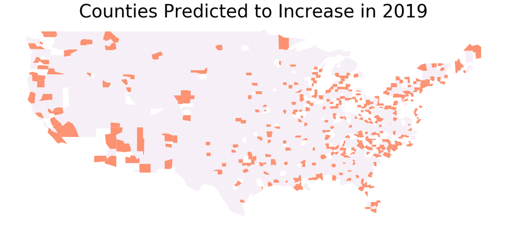

```python
cmap13 = LinearSegmentedColormap.from_list(
    'mycmap', [(0, '#f6eff7'), (1, '#fc9272')])
f, ax = plt.subplots(1, figsize=(20, 20))
ax = geodf[geodf.predicted_18 < 2].plot(column = 'predicted_18', ax = ax, cmap = cmap13)
plt.title('Counties Predicted to Increase in 2019', fontsize = 40)
ax.spines['right'].set_visible(False)
ax.spines['top'].set_visible(False)
ax.spines['left'].set_visible(False)
ax.spines['bottom'].set_visible(False)
ax.get_xaxis().set_visible(False)
ax.get_yaxis().set_visible(False)
plt.show()
```